# Portafolio del Curso de Métodos Numéricos

##### Continuación de sustitución hacia atrás - tercera columna

```r
Ab <- NuevaA; (Ab)
```

```
##    [,1] [,2]      [,3]      [,4]       [,5]
## R1    6    6  4.000000  0.000000  2.0434783
## R2    0   -3 -6.333333  0.000000  5.4710145
## R3    0    0 -6.555556  0.000000 -0.1425121
## R4    0    0  0.000000 -1.559322  3.1864407
```

```r
m10 <- -Ab[2,3]/Ab[3,3]; (m10)
```

```
##         R2
## -0.9661017
```

```r
m11 <- -Ab[1,3]/Ab[3,3]; (m11)
```

```
##        R1
## 0.6101695
```

```r
R2 <- m10*Ab[3,]+Ab[2,]; (R2)
```

```
## [1]  0.000000 -3.000000  0.000000  0.000000  5.608696
```

```r
R1 <- m11*Ab[3,]+Ab[1,]; (R1)
```

```
## [1] 6.000000 6.000000 0.000000 0.000000 1.956522
```

```r
NuevaA <- rbind(R1,R2,R3,R4); (NuevaA)
```

```
##    [,1] [,2]      [,3]      [,4]       [,5]
## R1    6    6  0.000000  0.000000  1.9565217
## R2    0   -3  0.000000  0.000000  5.6086957
## R3    0    0 -6.555556  0.000000 -0.1425121
## R4    0    0  0.000000 -1.559322  3.1864407
```

##### Continuación de sustitución hacia atrás - segunda columna

```r
Ab <- NuevaA; (Ab)
```

```
##    [,1] [,2]      [,3]      [,4]       [,5]
## R1    6    6  0.000000  0.000000  1.9565217
## R2    0   -3  0.000000  0.000000  5.6086957
## R3    0    0 -6.555556  0.000000 -0.1425121
## R4    0    0  0.000000 -1.559322  3.1864407
```

```r
m12 <- -Ab[1,2]/Ab[2,2]; (m12)
```

```
## R1
##  2
```

```r
R1 <- m12*Ab[2,]+Ab[1,]; (R1)
```

```
## [1]  6.00000  0.00000  0.00000  0.00000 13.17391
```

```r
NuevaA <- rbind(R1,R2,R3,R4); (NuevaA)
```

```
##    [,1] [,2]      [,3]      [,4]       [,5]
## R1    6    0  0.000000  0.000000 13.1739130
## R2    0   -3  0.000000  0.000000  5.6086957
## R3    0    0 -6.555556  0.000000 -0.1425121
## R4    0    0  0.000000 -1.559322  3.1864407
```

##### Obtener los valores de las variables desde la matriz final

```r
x <- NuevaA[1,5] / NuevaA[1,1]
y <- NuevaA[2,5] / NuevaA[2,2]
z <- NuevaA[3,5] / NuevaA[3,3]
w <- NuevaA[4,5] / NuevaA[4,4]
```

##### Mostrar los resultados

```r
cat("x =", x, "\n")
```

```
## x = 2.195652
```

```r
cat("y =", y, "\n")
```

```
## y = -1.869565
```

```r
cat("z =", z, "\n")
```

```
## z = 0.02173913
```

```r
cat("w =", w, "\n")
```

```
## w = -2.043478
```

#### ELIMINACION CON GAUSS JORDAN

##### Realizamos limpieza del entorno

Lo voy a realizar con lo que vimos en la clase del día de hoy, 23/Sep, realizamos limpieza

##### Definición de la matriz A (3x3)

```r
valores <- c(2,-3,-2,1,-1,1,-1,2,2);
A <- matrix(valores, nrow = 3); (A)
```

```
##      [,1] [,2] [,3]
## [1,]    2    1   -1
## [2,]   -3   -1    2
## [3,]   -2    1    2
```

##### Obtenemos la determinante

```r
detA <- A[1,1]*((A[2,2]*A[3,3])-(A[3,2]*A[2,3]))-A[1,2]*((A[2,1]*A[3,3])-(A[3,1]*A[2,3]))+A[1,3]*((A[2,1]*A[3,2])-(A[3,1]*A[2,2]));
(detA)
```

```
## [1] -1
```

##### Obtenemos b

```r
b <- c(8,-11,-3)
b <- matrix(b, nrow = 3); (b)
```

```
##      [,1]
## [1,]    8
## [2,]  -11
## [3,]   -3
```

##### Matriz identidad para calcular la inversa

Ocupamos otra matriz para sacar la inversa, esta va a ser diagonal de unos (identidad)

```r
valores <- c(1,0,0,0,1,0,0,0,1);
B <- matrix(valores, nrow = 3); (B)
```

```
##      [,1] [,2] [,3]
## [1,]    1    0    0
## [2,]    0    1    0
## [3,]    0    0    1
```

##### Matriz aumentada [A|I]

```r
AB <- cbind(A,B);
(AB)
```

```
##      [,1] [,2] [,3] [,4] [,5] [,6]
## [1,]    2    1   -1    1    0    0
## [2,]   -3   -1    2    0    1    0
## [3,]   -2    1    2    0    0    1
```

##### Análisis del pivote y primer intercambio

```r
# Analizamos si hay un absoluto mayor, para ponerlo encima
matrices_absoluta <- abs(AB);
(matrices_absoluta)
```

```
##      [,1] [,2] [,3] [,4] [,5] [,6]
## [1,]    2    1    1    1    0    0
## [2,]    3    1    2    0    1    0
## [3,]    2    1    2    0    0    1
```

```r
matrices_mayor <- max(matrices_absoluta )
cat("La matriz mayor es", (matrices_mayor))
```

```
## La matriz mayor es 3
```

```r
# Intercambiamos
R1 <- AB[2,]; (R1)
```

```
## [1] -3 -1  2  0  1  0
```

```r
R2 <- AB[1,]; (R2)
```

```
## [1]  2  1 -1  1  0  0
```

```r
R3 <- AB[3,]; (R3)
```

```
## [1] -2  1  2  0  0  1
```

```r
NuevaA <- rbind(R1,R2,R3); (NuevaA)
```

```
##    [,1] [,2] [,3] [,4] [,5] [,6]
## R1   -3   -1    2    0    1    0
## R2    2    1   -1    1    0    0
## R3   -2    1    2    0    0    1
```

##### Convertimos fila 1 a “1”

```r
AB <- NuevaA; (AB)
```

```
##    [,1] [,2] [,3] [,4] [,5] [,6]
## R1   -3   -1    2    0    1    0
## R2    2    1   -1    1    0    0
## R3   -2    1    2    0    0    1
```

```r
m1 <- 1/AB[1,1]; (m1)
```

```
##         R1
## -0.3333333
```

```r
R1 <- m1*AB[1,]
NuevaA <- rbind(R1,R2,R3); (NuevaA)
```

```
##    [,1]      [,2]       [,3] [,4]       [,5] [,6]
## R1    1 0.3333333 -0.6666667    0 -0.3333333    0
## R2    2 1.0000000 -1.0000000    1  0.0000000    0
## R3   -2 1.0000000  2.0000000    0  0.0000000    1
```

##### Eliminación en la primera columna (sin pivoteo)

No hay necesidad de hacer pivoteo

```r
AB <- NuevaA; (AB)
```

```
##    [,1]      [,2]       [,3] [,4]       [,5] [,6]
## R1    1 0.3333333 -0.6666667    0 -0.3333333    0
## R2    2 1.0000000 -1.0000000    1  0.0000000    0
## R3   -2 1.0000000  2.0000000    0  0.0000000    1
```

```r
m2 <- -AB[2,1]/AB[1,1]; (m2)
```

```
## R2
## -2
```

```r
m3 <- -AB[3,1]/AB[1,1]; (m3)
```

```
## R3
##  2
```

```r
R2 <- m2*AB[1,]+AB[2,]; (R2)
```

```
## [1] 0.0000000 0.3333333 0.3333333 1.0000000 0.6666667 0.0000000
```

```r
R3 <- m3*AB[1,]+AB[3,]; (R3)
```

```
## [1]  0.0000000  1.6666667  0.6666667  0.0000000 -0.6666667  1.0000000
```

```r
NuevaA <- rbind(R1,R2,R3); (NuevaA)
```

```
##    [,1]      [,2]       [,3] [,4]       [,5] [,6]
## R1    1 0.3333333 -0.6666667    0 -0.3333333    0
## R2    0 0.3333333  0.3333333    1  0.6666667    0
## R3    0 1.6666667  0.6666667    0 -0.6666667    1
```

##### Intercambio de filas para la segunda columna

```r
R1 <- NuevaA[1,];
R2 <- NuevaA[3,];
R3 <- NuevaA[2,];
AB <- rbind(R1,R2,R3); (AB)
```

```
##    [,1]      [,2]       [,3] [,4]       [,5] [,6]
## R1    1 0.3333333 -0.6666667    0 -0.3333333    0
## R2    0 1.6666667  0.6666667    0 -0.6666667    1
## R3    0 0.3333333  0.3333333    1  0.6666667    0
```

##### Convertimos Fila 2 a 1

```r
m4 <- 1/AB[2,2];
R2 <- m4*AB[2,]; (R2)
```

```
## [1]  0.0  1.0  0.4  0.0 -0.4  0.6
```

```r
NuevaA <- rbind(R1,R2,R3); (NuevaA)
```

```
##    [,1]      [,2]       [,3] [,4]       [,5] [,6]
## R1    1 0.3333333 -0.6666667    0 -0.3333333  0.0
## R2    0 1.0000000  0.4000000    0 -0.4000000  0.6
## R3    0 0.3333333  0.3333333    1  0.6666667  0.0
```

##### Eliminación en la segunda columna

```r
AB <- NuevaA; (AB)
```

```
##    [,1]      [,2]       [,3] [,4]       [,5] [,6]
## R1    1 0.3333333 -0.6666667    0 -0.3333333  0.0
## R2    0 1.0000000  0.4000000    0 -0.4000000  0.6
## R3    0 0.3333333  0.3333333    1  0.6666667  0.0
```

```r
m5 <- -AB[3,2]/AB[2,2];
R3 <- m5*AB[2,]+AB[3,];(R3)
```

```
## [1]  0.0  0.0  0.2  1.0  0.8 -0.2
```

```r
NuevaA <- rbind(R1,R2,R3); (NuevaA)
```

```
##    [,1]      [,2]       [,3] [,4]       [,5] [,6]
## R1    1 0.3333333 -0.6666667    0 -0.3333333  0.0
## R2    0 1.0000000  0.4000000    0 -0.4000000  0.6
## R3    0 0.0000000  0.2000000    1  0.8000000 -0.2
```

##### Convertimos Fila 3 a 1

```r
AB <- NuevaA; (AB)
```

```
##    [,1]      [,2]       [,3] [,4]       [,5] [,6]
## R1    1 0.3333333 -0.6666667    0 -0.3333333  0.0
## R2    0 1.0000000  0.4000000    0 -0.4000000  0.6
## R3    0 0.0000000  0.2000000    1  0.8000000 -0.2
```

```r
m6 <- 1/AB[3,3]; (m6)
```

```
## R3
##  5
```

```r
R3 <- m6*AB[3,]
NuevaA <- rbind(R1,R2,R3); (NuevaA)
```

```
##    [,1]      [,2]       [,3] [,4]       [,5] [,6]
## R1    1 0.3333333 -0.6666667    0 -0.3333333  0.0
## R2    0 1.0000000  0.4000000    0 -0.4000000  0.6
## R3    0 0.0000000  1.0000000    5  4.0000000 -1.0
```

##### Eliminación hacia atrás en la tercera columna

```r
AB <- NuevaA; (AB) # Importante agregar
```

```
##    [,1]      [,2]       [,3] [,4]       [,5] [,6]
## R1    1 0.3333333 -0.6666667    0 -0.3333333  0.0
## R2    0 1.0000000  0.4000000    0 -0.4000000  0.6
## R3    0 0.0000000  1.0000000    5  4.0000000 -1.0
```

```r
m7 <- -AB[2,3]/AB[3,3];
m8 <- -AB[1,3]/AB[3,3];
R2 <- m7*AB[3,]+AB[2,];(R2)
```

```
## [1]  0  1  0 -2 -2  1
```

```r
R1 <- m8*AB[3,]+AB[1,];(R1)
```

```
## [1]  1.0000000  0.3333333  0.0000000  3.3333333  2.3333333 -0.6666667
```

```r
NuevaA <- rbind(R1,R2,R3); (NuevaA) # De igual manera importante de agregar
```

```
##    [,1]      [,2] [,3]      [,4]      [,5]       [,6]
## R1    1 0.3333333    0  3.333333  2.333333 -0.6666667
## R2    0 1.0000000    0 -2.000000 -2.000000  1.0000000
## R3    0 0.0000000    1  5.000000  4.000000 -1.0000000
```

##### Eliminación hacia atrás en la segunda columna

```r
AB <- NuevaA; (AB)
```

```
##    [,1]      [,2] [,3]      [,4]      [,5]       [,6]
## R1    1 0.3333333    0  3.333333  2.333333 -0.6666667
## R2    0 1.0000000    0 -2.000000 -2.000000  1.0000000
## R3    0 0.0000000    1  5.000000  4.000000 -1.0000000
```

```r
m9 <- -AB[1,2]/AB[2,2];
R1 <- m9*AB[2,]+AB[1,];(R1)
```

```
## [1]  1  0  0  4  3 -1
```

```r
NuevaA <- rbind(R1,R2,R3); (NuevaA)
```

```
##    [,1] [,2] [,3] [,4] [,5] [,6]
## R1    1    0    0    4    3   -1
## R2    0    1    0   -2   -2    1
## R3    0    0    1    5    4   -1
```

##### Extraemos la matriz inversa

```r
AB <- NuevaA; (AB)
```

```
##    [,1] [,2] [,3] [,4] [,5] [,6]
## R1    1    0    0    4    3   -1
## R2    0    1    0   -2   -2    1
## R3    0    0    1    5    4   -1
```

```r
resul <- c(AB[1,4],AB[2,4],AB[3,4],AB[1,5],AB[2,5],AB[3,5],AB[1,6],AB[2,6],AB[3,6]);
inverA <- matrix(resul, nrow = 3); (inverA)
```

```
##      [,1] [,2] [,3]
## [1,]    4    3   -1
## [2,]   -2   -2    1
## [3,]    5    4   -1
```

##### Multiplicamos matrices A^-1 por b

```r
resultado <- (inverA%*%b); (resultado)
```

```
##      [,1]
## [1,]    2
## [2,]    3
## [3,]   -1
```

### Practica del dia 24

#### INVERSA DE UNA MATRIZ

##### Definición de la matriz A original

```r
A=matrix(c(1,3,-2,1,1,4,-1,2,0,1,-1,4,2,6,1,2),nrow = 4,byrow = TRUE)
(A)
```

```
##      [,1] [,2] [,3] [,4]
## [1,]    1    3   -2    1
## [2,]    1    4   -1    2
## [3,]    0    1   -1    4
## [4,]    2    6    1    2
```

```r
Aorig<- A
```

##### Creación de la matriz identidad

```r
I = diag(4);(I)
```

```
##      [,1] [,2] [,3] [,4]
## [1,]    1    0    0    0
## [2,]    0    1    0    0
## [3,]    0    0    1    0
## [4,]    0    0    0    1
```

##### Construcción de la matriz aumentada [A|I]

```r
AInv <- cbind(A,I); (AInv)
```

```
##      [,1] [,2] [,3] [,4] [,5] [,6] [,7] [,8]
## [1,]    1    3   -2    1    1    0    0    0
## [2,]    1    4   -1    2    0    1    0    0
## [3,]    0    1   -1    4    0    0    1    0
## [4,]    2    6    1    2    0    0    0    1
```

```r
A <- AInv
```

##### Cálculo de multiplicadores para la primera columna

```r
l21 <- A[2,1]/A[1,1];(l21)
```

```
## [1] 1
```

```r
l31 <- A[3,1]/A[1,1];(l31)
```

```
## [1] 0
```

```r
l41 <- A[4,1]/A[1,1];(l41)
```

```
## [1] 2
```

##### Eliminación en la primera columna

```r
A[2,] <- A[2,]-l21*A[1,];
A[3,] <- A[3,]-l31*A[1,];
A[4,] <- A[4,]-l41*A[1,];
(A)
```

```
##      [,1] [,2] [,3] [,4] [,5] [,6] [,7] [,8]
## [1,]    1    3   -2    1    1    0    0    0
## [2,]    0    1    1    1   -1    1    0    0
## [3,]    0    1   -1    4    0    0    1    0
## [4,]    0    0    5    0   -2    0    0    1
```

##### Intercambio de filas 2 y 3

```r
Atmp <- A[2,]
A[2,] <- A[3,]
A[3,] <- Atmp
(A)
```

```
##      [,1] [,2] [,3] [,4] [,5] [,6] [,7] [,8]
## [1,]    1    3   -2    1    1    0    0    0
## [2,]    0    1   -1    4    0    0    1    0
## [3,]    0    1    1    1   -1    1    0    0
## [4,]    0    0    5    0   -2    0    0    1
```

##### Cálculo de multiplicadores para la segunda columna

```r
l32 <- A[3,2]/A[2,2];(l32)
```

```
## [1] 1
```

```r
l42 <- A[4,2]/A[2,2];(l42)
```

```
## [1] 0
```

##### Eliminación en la segunda columna

```r
A[3,] <- A[3,]-l32*A[2,];
A[4,] <- A[4,]-l42*A[2,];
(A)
```

```
##      [,1] [,2] [,3] [,4] [,5] [,6] [,7] [,8]
## [1,]    1    3   -2    1    1    0    0    0
## [2,]    0    1   -1    4    0    0    1    0
## [3,]    0    0    2   -3   -1    1   -1    0
## [4,]    0    0    5    0   -2    0    0    1
```

##### Normalización de la fila 3

```r
esc <- 1/A[3,3]
A[3,] <- esc*A[3,]
(A)
```

```
##      [,1] [,2] [,3] [,4] [,5] [,6] [,7] [,8]
## [1,]    1    3   -2  1.0  1.0  0.0  0.0    0
## [2,]    0    1   -1  4.0  0.0  0.0  1.0    0
## [3,]    0    0    1 -1.5 -0.5  0.5 -0.5    0
## [4,]    0    0    5  0.0 -2.0  0.0  0.0    1
```

##### Cálculo de multiplicador para eliminar en fila 4

```r
l43 <- A[4,3]/A[3,3];(l43)
```

```
## [1] 5
```

##### Eliminación en la tercera columna

```r
A[4,] <- A[4,]-l43*A[3,];
(A)
```

```
##      [,1] [,2] [,3] [,4] [,5] [,6] [,7] [,8]
## [1,]    1    3   -2  1.0  1.0  0.0  0.0    0
## [2,]    0    1   -1  4.0  0.0  0.0  1.0    0
## [3,]    0    0    1 -1.5 -0.5  0.5 -0.5    0
## [4,]    0    0    0  7.5  0.5 -2.5  2.5    1
```

##### Normalización de la fila 4

```r
esc <- 1/A[4,4]
A[4,] <- esc*A[4,]
(A)
```

```
##      [,1] [,2] [,3] [,4]        [,5]       [,6]       [,7]      [,8]
## [1,]    1    3   -2  1.0  1.00000000  0.0000000  0.0000000 0.0000000
## [2,]    0    1   -1  4.0  0.00000000  0.0000000  1.0000000 0.0000000
## [3,]    0    0    1 -1.5 -0.50000000  0.5000000 -0.5000000 0.0000000
## [4,]    0    0    0  1.0  0.06666667 -0.3333333  0.3333333 0.1333333
```

##### Sustitución hacia atrás - cuarta columna

```r
l34 <- A[3,4]/A[4,4];(l34); A[3,] <- A[3,]-l34*A[4,]
```

```
## [1] -1.5
```

```r
l24 <- A[2,4]/A[4,4];(l24); A[2,] <- A[2,]-l24*A[4,]
```

```
## [1] 4
```

```r
l14 <- A[1,4]/A[4,4];(l14); A[1,] <- A[1,]-l14*A[4,]
```

```
## [1] 1
```

```r
(A)
```

```
##      [,1] [,2] [,3] [,4]        [,5]       [,6]       [,7]       [,8]
## [1,]    1    3   -2    0  0.93333333  0.3333333 -0.3333333 -0.1333333
## [2,]    0    1   -1    0 -0.26666667  1.3333333 -0.3333333 -0.5333333
## [3,]    0    0    1    0 -0.40000000  0.0000000  0.0000000  0.2000000
## [4,]    0    0    0    1  0.06666667 -0.3333333  0.3333333  0.1333333
```

##### Sustitución hacia atrás - tercera columna

```r
l23 <- A[2,3]/A[3,3];(l23); A[2,] <- A[2,]-l23*A[3,]
```

```
## [1] -1
```

```r
l13 <- A[1,3]/A[3,3];(l13); A[1,] <- A[1,]-l13*A[3,]
```

```
## [1] -2
```

```r
(A)
```

```
##      [,1] [,2] [,3] [,4]        [,5]       [,6]       [,7]       [,8]
## [1,]    1    3    0    0  0.13333333  0.3333333 -0.3333333  0.2666667
## [2,]    0    1    0    0 -0.66666667  1.3333333 -0.3333333 -0.3333333
## [3,]    0    0    1    0 -0.40000000  0.0000000  0.0000000  0.2000000
## [4,]    0    0    0    1  0.06666667 -0.3333333  0.3333333  0.1333333
```

##### Sustitución hacia atrás - segunda columna

```r
l12 <- A[1,2]/A[2,2];(l12); A[1,] <- A[1,]-l12*A[2,]
```

```
## [1] 3
```

```r
(A)
```

```
##      [,1] [,2] [,3] [,4]        [,5]       [,6]       [,7]       [,8]
## [1,]    1    0    0    0  2.13333333 -3.6666667  0.6666667  1.2666667
## [2,]    0    1    0    0 -0.66666667  1.3333333 -0.3333333 -0.3333333
## [3,]    0    0    1    0 -0.40000000  0.0000000  0.0000000  0.2000000
## [4,]    0    0    0    1  0.06666667 -0.3333333  0.3333333  0.1333333
```

##### Extracción de la matriz inversa

```r
AInv <- A[,5:8]; (AInv)
```

```
##             [,1]       [,2]       [,3]       [,4]
## [1,]  2.13333333 -3.6666667  0.6666667  1.2666667
## [2,] -0.66666667  1.3333333 -0.3333333 -0.3333333
## [3,] -0.40000000  0.0000000  0.0000000  0.2000000
## [4,]  0.06666667 -0.3333333  0.3333333  0.1333333
```

##### Verificación: A * A^-1 = I

```r
IdCalc <- Aorig%*%AInv; (IdCalc)
```

```
##               [,1]          [,2]         [,3]          [,4]
## [1,]  1.000000e+00 -5.551115e-17 5.551115e-17 -2.775558e-17
## [2,] -3.053113e-16  1.000000e+00 1.110223e-16  0.000000e+00
## [3,] -5.551115e-17  0.000000e+00 1.000000e+00  0.000000e+00
## [4,] -5.273559e-16 -1.110223e-16 1.110223e-16  1.000000e+00
```

#### FACTORIZACION LU

##### Ejemplo 1

###### Definición de la matriz A

```r
A=matrix(c(1,1,1,1,2,3,1,5,-1,1,-5,3,3,1,7,-2),byrow = TRUE,nrow = 4); (A)
```

```
##      [,1] [,2] [,3] [,4]
## [1,]    1    1    1    1
## [2,]    2    3    1    5
## [3,]   -1    1   -5    3
## [4,]    3    1    7   -2
```

###### Definición del vector b

```r
b=matrix(c(10,31,-2,18),nrow = 4);(b)
```

```
##      [,1]
## [1,]   10
## [2,]   31
## [3,]   -2
## [4,]   18
```

###### Construcción de la matriz aumentada

```r
Ab <- cbind(A,b); (Ab)
```

```
##      [,1] [,2] [,3] [,4] [,5]
## [1,]    1    1    1    1   10
## [2,]    2    3    1    5   31
## [3,]   -1    1   -5    3   -2
## [4,]    3    1    7   -2   18
```

###### Cálculo de multiplicadores para la primera columna

Los pivotes se definen como $a_{kk}^{(k)}$, luego construimos los multiplicadores: $l_{i,k}=a_{ik}^{(k)}/a_{kk}^{(k)}$, $l_{21}=a_{21}/a_{11}$ y $l_{31}=a_{31}/a_{11}$ y $l_{41}=a_{41}/a_{11}$

```r
A <- Ab;
l21 <- A[2,1]/A[1,1];(l21)
```

```
## [1] 2
```

```r
l31 <- A[3,1]/A[1,1];(l31)
```

```
## [1] -1
```

```r
l41 <- A[4,1]/A[1,1];(l41)
```

```
## [1] 3
```

###### Construcción de la matriz U - primera columna

Construimos la matriz $U$, donde las entradas $a_{ij}^{(k+1)}=a_{ik}^{(k)}-l_{ik}\times a_{kj}^{(k)}$

```r
A[2,] <- A[2,]-l21*A[1,]; (A[2,])
```

```
## [1]  0  1 -1  3 11
```

```r
A[3,] <- A[3,]-l31*A[1,]; (A[3,])
```

```
## [1]  0  2 -4  4  8
```

```r
A[4,] <- A[4,]-l41*A[1,]; (A[4,])
```

```
## [1]   0  -2   4  -5 -12
```

###### Matriz resultante después del primer paso

```r
(A)
```

```
##      [,1] [,2] [,3] [,4] [,5]
## [1,]    1    1    1    1   10
## [2,]    0    1   -1    3   11
## [3,]    0    2   -4    4    8
## [4,]    0   -2    4   -5  -12
```

###### Cálculo de multiplicadores para la segunda columna

Entonces el pivote es $A_{22} = 1$, calculemos los $l_{32}$ y $l_{42}$

```r
l32 <- A[3,2]/A[2,2];(l32)
```

```
## [1] 2
```

```r
l42 <- A[4,2]/A[2,2];(l42)
```

```
## [1] -2
```

###### Haciendo cero debajo del pivote en columna 2

```r
A[3,] <- A[3,]-l32*A[2,];(A[3,])
```

```
## [1]   0   0  -2  -2 -14
```

```r
A[4,] <- A[4,]-l42*A[2,];(A[4,])
```

```
## [1]  0  0  2  1 10
```

###### Matriz resultante después del segundo paso

```r
(A)
```

```
##      [,1] [,2] [,3] [,4] [,5]
## [1,]    1    1    1    1   10
## [2,]    0    1   -1    3   11
## [3,]    0    0   -2   -2  -14
## [4,]    0    0    2    1   10
```

###### Cálculo del último multiplicador

Por tanto el pivote es $A_{33}=-2$, y resta calcular $l_{43}$

```r
l43 <- A[4,3]/A[3,3];(l43)
```

```
## [1] -1
```

###### Haciendo cero debajo del pivote en columna 3

```r
A[4,] <- A[4,]-l43*A[3,];(A[4,])
```

```
## [1]  0  0  0 -1 -4
```

###### Matriz A final

```r
(A)
```

```
##      [,1] [,2] [,3] [,4] [,5]
## [1,]    1    1    1    1   10
## [2,]    0    1   -1    3   11
## [3,]    0    0   -2   -2  -14
## [4,]    0    0    0   -1   -4
```

###### Construcción de la matriz L

Entonces podemos construir la matriz $L$ con los valores $l_{ij}$ calculados en los pasos anteriores

```r
L=diag(4);(L)
```

```
##      [,1] [,2] [,3] [,4]
## [1,]    1    0    0    0
## [2,]    0    1    0    0
## [3,]    0    0    1    0
## [4,]    0    0    0    1
```

```r
L[2,1] <- l21
L[3,1] <- l31
L[4,1] <- l41
L[3,2] <- l32
L[4,2] <- l42
L[4,3] <- l43
(L)
```

```
##      [,1] [,2] [,3] [,4]
## [1,]    1    0    0    0
## [2,]    2    1    0    0
## [3,]   -1    2    1    0
## [4,]    3   -2   -1    1
```

###### Extracción de la matriz U

```r
U <- A[,1:4];(U)
```

```
##      [,1] [,2] [,3] [,4]
## [1,]    1    1    1    1
## [2,]    0    1   -1    3
## [3,]    0    0   -2   -2
## [4,]    0    0    0   -1
```

###### Verificación: A = LU

```r
Acalculada <- L%*%U; (Acalculada)
```

```
##      [,1] [,2] [,3] [,4]
## [1,]    1    1    1    1
## [2,]    2    3    1    5
## [3,]   -1    1   -5    3
## [4,]    3    1    7   -2
```

##### Ejemplo 2

###### Definición de la matriz A para el ejemplo 2

Apliquemos lo desarrollado para la siguiente matriz $A$

```r
A=matrix(c(4,0,1,1,3,1,3,1,0,1,2,0,3,2,4,1),nrow = 4,byrow = TRUE); (A)
```

```
##      [,1] [,2] [,3] [,4]
## [1,]    4    0    1    1
## [2,]    3    1    3    1
## [3,]    0    1    2    0
## [4,]    3    2    4    1
```

###### Definición del vector b para el ejemplo 2

```r
b=matrix(c(5,6,13,1),nrow = 4);(b)
```

```
##      [,1]
## [1,]    5
## [2,]    6
## [3,]   13
## [4,]    1
```

###### Construcción de la matriz aumentada

```r
Ab <- cbind(A,b)
A <- Ab;
```

###### Cálculo de multiplicadores para la primera columna

```r
l21 <- A[2,1]/A[1,1];(l21)
```

```
## [1] 0.75
```

```r
l31 <- A[3,1]/A[1,1];(l31)
```

```
## [1] 0
```

```r
l41 <- A[4,1]/A[1,1];(l41)
```

```
## [1] 0.75
```

###### Eliminación en la primera columna

```r
A[2,] <- A[2,]-l21*A[1,]; (A[2,])
```

```
## [1] 0.00 1.00 2.25 0.25 2.25
```

```r
A[3,] <- A[3,]-l31*A[1,]; (A[3,])
```

```
## [1]  0  1  2  0 13
```

```r
A[4,] <- A[4,]-l41*A[1,]; (A[4,])
```

```
## [1]  0.00  2.00  3.25  0.25 -2.75
```

###### Cálculo de multiplicadores para la segunda columna

```r
l32 <- A[3,2]/A[2,2];(l32)
```

```
## [1] 1
```

```r
l42 <- A[4,2]/A[2,2];(l42)
```

```
## [1] 2
```

###### Eliminación en la segunda columna

```r
A[3,] <- A[3,]-l32*A[2,];(A[3,])
```

```
## [1]  0.00  0.00 -0.25 -0.25 10.75
```

```r
A[4,] <- A[4,]-l42*A[2,];(A[4,])
```

```
## [1]  0.00  0.00 -1.25 -0.25 -7.25
```

###### Cálculo del último multiplicador

```r
l43 <- A[4,3]/A[3,3];(l43)
```

```
## [1] 5
```

###### Eliminación en la tercera columna

```r
A[4,] <- A[4,]-l43*A[3,];(A[4,])
```

```
## [1]   0   0   0   1 -61
```

###### Construcción de la matriz L

```r
L=diag(4);(L)
```

```
##      [,1] [,2] [,3] [,4]
## [1,]    1    0    0    0
## [2,]    0    1    0    0
## [3,]    0    0    1    0
## [4,]    0    0    0    1
```

```r
L[2,1] <- l21
L[3,1] <- l31
L[4,1] <- l41
L[3,2] <- l32
L[4,2] <- l42
L[4,3] <- l43;
(L)
```

```
##      [,1] [,2] [,3] [,4]
## [1,] 1.00    0    0    0
## [2,] 0.75    1    0    0
## [3,] 0.00    1    1    0
## [4,] 0.75    2    5    1
```

###### Extracción de la matriz U

```r
U <- A[,1:4];(U)
```

```
##      [,1] [,2]  [,3]  [,4]
## [1,]    4    0  1.00  1.00
## [2,]    0    1  2.25  0.25
## [3,]    0    0 -0.25 -0.25
## [4,]    0    0  0.00  1.00
```

###### Verificación: A = LU

```r
Acalculada <- L%*%U; (Acalculada)
```

```
##      [,1] [,2] [,3] [,4]
## [1,]    4    0    1    1
## [2,]    3    1    3    1
## [3,]    0    1    2    0
## [4,]    3    2    4    1
```

##### Ejercicio

###### Definición de la matriz A del ejercicio

Aplicar la factorización $LU$ a la matriz A definida por

```r
A=matrix(c(2,3,2,4,
           4,10,-4,0,
           -3,-2,-5,-2,
           -2,4,4,-7),nrow = 4,byrow = TRUE)
(A)
```

```
##      [,1] [,2] [,3] [,4]
## [1,]    2    3    2    4
## [2,]    4   10   -4    0
## [3,]   -3   -2   -5   -2
## [4,]   -2    4    4   -7
```

###### Vector b del ejercicio

Usamos del Ejemplo 1 la matriz *b*

```r
b=matrix(c(10,31,-2,18),nrow = 4);(b)
```

```
##      [,1]
## [1,]   10
## [2,]   31
## [3,]   -2
## [4,]   18
```

###### Matriz aumentada del ejercicio

```r
Ab <- cbind(A,b); (Ab)
```

```
##      [,1] [,2] [,3] [,4] [,5]
## [1,]    2    3    2    4   10
## [2,]    4   10   -4    0   31
## [3,]   -3   -2   -5   -2   -2
## [4,]   -2    4    4   -7   18
```

###### Cálculo de multiplicadores para la primera columna

Guardamos y seguimos operando sacando nuestra primera *“l”*

```r
A <- Ab;
l21 <- A[2,1]/A[1,1]; (l21)
```

```
## [1] 2
```

```r
l31 <- A[3,1]/A[1,1]; (l31)
```

```
## [1] -1.5
```

```r
l41 <- A[4,1]/A[1,1]; (l41)
```

```
## [1] -1
```

###### Reconstrucción de la matriz

```r
A[2,] <- A[2,]-l21*A[1,]; (A[2,])
```

```
## [1]  0  4 -8 -8 11
```

```r
A[3,] <- A[3,]-l31*A[1,]; (A[3,])
```

```
## [1]  0.0  2.5 -2.0  4.0 13.0
```

```r
A[4,] <- A[4,]-l41*A[1,]; (A[4,])
```

```
## [1]  0  7  6 -3 28
```

###### Matriz resultante

```r
(A)
```

```
##      [,1] [,2] [,3] [,4] [,5]
## [1,]    2  3.0    2    4   10
## [2,]    0  4.0   -8   -8   11
## [3,]    0  2.5   -2    4   13
## [4,]    0  7.0    6   -3   28
```

###### Cálculo de multiplicadores para la segunda columna

Creamos las siguientes *“l”*

```r
l32 <- A[3,2]/A[2,2];(l32)
```

```
## [1] 0.625
```

```r
l42 <- A[4,2]/A[2,2];(l42)
```

```
## [1] 1.75
```

###### Haciendo ceros debajo del segundo pivote

```r
A[3,] <- A[3,]-l32*A[2,];(A[3,])
```

```
## [1] 0.000 0.000 3.000 9.000 6.125
```

```r
A[4,] <- A[4,]-l42*A[2,];(A[4,])
```

```
## [1]  0.00  0.00 20.00 11.00  8.75
```

###### Matriz resultante después del segundo paso

```r
(A)
```

```
##      [,1] [,2] [,3] [,4]   [,5]
## [1,]    2    3    2    4 10.000
## [2,]    0    4   -8   -8 11.000
## [3,]    0    0    3    9  6.125
## [4,]    0    0   20   11  8.750
```

###### Cálculo del último multiplicador

Procedemos a calcular el último l

```r
l43 <- A[4,3]/A[3,3];(l43)
```

```
## [1] 6.666667
```

###### Conversión de la última fila

```r
A[4,] <- A[4,]-l43*A[3,];(A[4,])
```

```
## [1]   0.00000   0.00000   0.00000 -49.00000 -32.08333
```

###### Creación de la matriz identidad L

Una vez realizado llamamos nuestra matriz diagonal

```r
L=diag(4);(L)
```

```
##      [,1] [,2] [,3] [,4]
## [1,]    1    0    0    0
## [2,]    0    1    0    0
## [3,]    0    0    1    0
## [4,]    0    0    0    1
```

###### Asignación de los multiplicadores a L

Le agregamos a esta los valores de los pivotes que calculamos con anterioridad

```r
L[2,1] <- l21
L[3,1] <- l31
L[4,1] <- l41
L[3,2] <- l32
L[4,2] <- l42
L[4,3] <- l43;
(L)
```

```
##      [,1]  [,2]     [,3] [,4]
## [1,]  1.0 0.000 0.000000    0
## [2,]  2.0 1.000 0.000000    0
## [3,] -1.5 0.625 1.000000    0
## [4,] -1.0 1.750 6.666667    1
```

###### Extracción de la matriz U

Llamamos la matriz *A* a excepción de la columna 5

```r
U <- A[,1:4];(U)
```

```
##      [,1] [,2] [,3] [,4]
## [1,]    2    3    2    4
## [2,]    0    4   -8   -8
## [3,]    0    0    3    9
## [4,]    0    0    0  -49
```

###### Verificación final: A = LU

Multiplicamos U y L para que nos dé la matriz A

```r
Acalculada <- L%*%U; (Acalculada)
```

```
##      [,1] [,2] [,3] [,4]
## [1,]    2    3    2    4
## [2,]    4   10   -4    0
## [3,]   -3   -2   -5   -2
## [4,]   -2    4    4   -7
```

#### NOTAS IMPORTANTES

**Nota 1** Si se fija $l_{ii}=1$ se le denomina factorización *Doolittle*.

**Nota 2** Una matriz $A$ tiene factorización de Doolittle si y sólo si se le puede aplicar el método de eliminación de Gauss sin pivoteo.

**Nota 3** Si $U=L^{T}$ entonces la factorización se le denomina *factorización de Cholesky*.

**Nota 4** Si la matriz es simétrica y definida positiva, entonces $A=LL^{T}$.

## Octubre

### Practica del dia 1

#### METODO DE GAUSS-SEIDEL

##### Definición de la matriz A y vector b

```r
A <- matrix(c(
  4,-1, 0, 0, 0,
 -1, 4,-1, 0, 0,
  0,-1, 4,-1, 0,
  0, 0,-1, 4,-1,
  0, 0, 0,-1, 4
), nrow = 5, byrow = TRUE)
b <- c(1,2,3,4,5)
```

##### Fórmula del método de Gauss-Seidel

$$x_i^{(k+1)} = \frac{1}{a_{ii}}\left( b_i - \sum_{j<i} a_{ij}
x_j^{(k+1)} - \sum_{j>i} a_{ij} x_j^{(k)} \right).$$

##### Vector inicial x^(0)

```r
x <- rep(0,5)  # x^(0) = (0,0,0,0,0)
cat("x^(0) =", paste(sprintf("%.8f", x), collapse=", "), "\n")
```

```
## x^(0) = 0.00000000, 0.00000000, 0.00000000, 0.00000000, 0.00000000
```

#### ITERACION 1

##### Preparación de la iteración 1

```r
x_old <- x
cat("\nIteración 1\n")
```

```
##
## Iteración 1
```

##### Cálculo de x1^(1)

Fila 1: $4x_1 - x_2 = 1 \rightarrow x_1 = \frac{1 + x_2^{(0)}}{4}$

```r
x[1] <- (b[1] + x_old[2]) / A[1,1]
cat(sprintf("x1^(1) = (1 + %g)/4 = %.8f\n", x_old[2], x[1]))
```

```
## x1^(1) = (1 + 0)/4 = 0.25000000
```

##### Cálculo de x2^(1)

Fila 2: $-x_1 + 4x_2 - x_3 = 2 \rightarrow x_2 = \frac{2 + x_1^{(1)} + x_3^{(0)}}{4}$

```r
x[2] <- (b[2] + x[1] + x_old[3]) / A[2,2]
cat(sprintf("x2^(1) = (2 + %.8f + %g)/4 = %.8f\n", x[1], x_old[3], x[2]))
```

```
## x2^(1) = (2 + 0.25000000 + 0)/4 = 0.56250000
```

##### Cálculo de x3^(1)

Fila 3: $-x_2 + 4x_3 - x_4 = 3 \rightarrow x_3 = \frac{3 + x_2^{(1)} + x_4^{(0)}}{4}$

```r
x[3] <- (b[3] + x[2] + x_old[4]) / A[3,3]
cat(sprintf("x3^(1) = (3 + %.8f + %g)/4 = %.8f\n", x[2], x_old[4], x[3]))
```

```
## x3^(1) = (3 + 0.56250000 + 0)/4 = 0.89062500
```

##### Cálculo de x4^(1)

Fila 4: $-x_3 + 4x_4 - x_5 = 4 \rightarrow x_4 = \frac{4 + x_3^{(1)} + x_5^{(0)}}{4}$

```r
x[4] <- (b[4] + x[3] + x_old[5]) / A[4,4]
cat(sprintf("x4^(1) = (4 + %.8f + %g)/4 = %.8f\n", x[3], x_old[5], x[4]))
```

```
## x4^(1) = (4 + 0.89062500 + 0)/4 = 1.22265625
```

##### Cálculo de x5^(1)

Fila 5: $-x_4 + 4x_5 = 5 \rightarrow x_5 = \frac{5 + x_4^{(1)}}{4}$

```r
x[5] <- (b[5] + x[4]) / A[5,5]
cat(sprintf("x5^(1) = (5 + %.8f)/4 = %.8f\n", x[4], x[5]))
```

```
## x5^(1) = (5 + 1.22265625)/4 = 1.55566406
```

##### Normas para la iteración 1

```r
r <- b - A %*% x
dx_inf <- max(abs(x - x_old))
cat(sprintf("x^(1) = %s\n", paste(sprintf("%.8f", x), collapse=", ")))
```

```
## x^(1) = 0.25000000, 0.56250000, 0.89062500, 1.22265625, 1.55566406
```

```r
cat(sprintf("||dx||_inf = %.8e | ||r||_inf = %.8e\n", dx_inf, max(abs(r))))
```

```
## ||dx||_inf = 1.55566406e+00 | ||r||_inf = 1.55566406e+00
```

##### Desarrollo matemático de la iteración 1

Usando $x^{(0)}=0$:

$$\begin{aligned}
x_1^{(1)} &= \frac{1+x_2^{(0)}}{4} = \frac{1+0}{4} = 0.25, \\
x_2^{(1)} &= \frac{2+x_1^{(1)}+x_3^{(0)}}{4} = \frac{2+0.25+0}{4} =
0.5625, \\
x_3^{(1)} &= \frac{3+x_2^{(1)}+x_4^{(0)}}{4} = \frac{3+0.5625+0}{4}
= 0.890625, \\
x_4^{(1)} &= \frac{4+x_3^{(1)}+x_5^{(0)}}{4} =
\frac{4+0.890625+0}{4} = 1.22265625, \\
x_5^{(1)} &= \frac{5+x_4^{(1)}}{4} = \frac{5+1.22265625}{4} =
1.5556640625.
\end{aligned}$$

#### ITERACION 2

##### Preparación de la iteración 2

```r
cat("\nIteración 2\n")
```

```
##
## Iteración 2
```

```r
x_old <- x
```

##### Cálculo de x1^(2)

```r
x[1] <- (b[1] + x_old[2]) / A[1,1]
cat(sprintf("x1^(2) = (1 + %.8f)/4 = %.8f\n", x_old[2], x[1]))
```

```
## x1^(2) = (1 + 0.56250000)/4 = 0.39062500
```

##### Cálculo de x2^(2)

```r
x[2] <- (b[2] + x[1] + x_old[3]) / A[2,2]
cat(sprintf("x2^(2) = (2 + %.8f + %.8f)/4 = %.8f\n", x[1], x_old[3], x[2]))
```

```
## x2^(2) = (2 + 0.39062500 + 0.89062500)/4 = 0.82031250
```

##### Cálculo de x3^(2)

```r
x[3] <- (b[3] + x[2] + x_old[4]) / A[3,3]
cat(sprintf("x3^(2) = (3 + %.8f + %.8f)/4 = %.8f\n", x[2], x_old[4], x[3]))
```

```
## x3^(2) = (3 + 0.82031250 + 1.22265625)/4 = 1.26074219
```

##### Cálculo de x4^(2)

```r
x[4] <- (b[4] + x[3] + x_old[5]) / A[4,4]
cat(sprintf("x4^(2) = (4 + %.8f + %.8f)/4 = %.8f\n", x[3], x_old[5], x[4]))
```

```
## x4^(2) = (4 + 1.26074219 + 1.55566406)/4 = 1.70410156
```

##### Cálculo de x5^(2)

```r
x[5] <- (b[5] + x[4]) / A[5,5]
cat(sprintf("x5^(2) = (5 + %.8f)/4 = %.8f\n", x[4], x[5]))
```

```
## x5^(2) = (5 + 1.70410156)/4 = 1.67602539
```

##### Normas para la iteración 2

```r
r <- b - A %*% x
dx_inf <- max(abs(x - x_old))
cat(sprintf("x^(2) = %s\n", paste(sprintf("%.8f", x), collapse=", ")))
```

```
## x^(2) = 0.39062500, 0.82031250, 1.26074219, 1.70410156, 1.67602539
```

```r
cat(sprintf("||dx||_inf = %.8e | ||r||_inf = %.8e\n", dx_inf, max(abs(r))))
```

```
## ||dx||_inf = 4.81445312e-01 | ||r||_inf = 4.81445312e-01
```

##### Desarrollo matemático de la iteración 2

$$\begin{aligned}
x_1^{(2)} &= \frac{1+x_2^{(1)}}{4} = \frac{1+0.5625}{4} = 0.390625,
\\
x_2^{(2)} &= \frac{2+x_1^{(2)}+x_3^{(1)}}{4} =
\frac{2+0.390625+0.890625}{4} = 0.8203125, \\
x_3^{(2)} &= \frac{3+x_2^{(2)}+x_4^{(1)}}{4} =
\frac{3+0.8203125+1.22265625}{4} = 1.2607421875, \\
x_4^{(2)} &= \frac{4+x_3^{(2)}+x_5^{(1)}}{4} =
\frac{4+1.2607421875+1.5556640625}{4} = 1.7041015625, \\
x_5^{(2)} &= \frac{5+x_4^{(2)}}{4} = \frac{5+1.7041015625}{4} =
1.676025390625.
\end{aligned}$$

#### ITERACION 3

##### Preparación de la iteración 3

```r
cat("\nIteración 3\n")
```

```
##
## Iteración 3
```

```r
x_old <- x
```

##### Cálculo de x1^(3)

```r
x[1] <- (b[1] + x_old[2]) / A[1,1]
cat(sprintf("x1^(3) = (1 + %.8f)/4 = %.8f\n", x_old[2], x[1]))
```

```
## x1^(3) = (1 + 0.82031250)/4 = 0.45507812
```

##### Cálculo de x2^(3)

```r
x[2] <- (b[2] + x[1] + x_old[3]) / A[2,2]
cat(sprintf("x2^(3) = (2 + %.8f + %.8f)/4 = %.8f\n", x[1], x_old[3], x[2]))
```

```
## x2^(3) = (2 + 0.45507812 + 1.26074219)/4 = 0.92895508
```

##### Cálculo de x3^(3)

```r
x[3] <- (b[3] + x[2] + x_old[4]) / A[3,3]
cat(sprintf("x3^(3) = (3 + %.8f + %.8f)/4 = %.8f\n", x[2], x_old[4], x[3]))
```

```
## x3^(3) = (3 + 0.92895508 + 1.70410156)/4 = 1.40826416
```

##### Cálculo de x4^(3)

```r
x[4] <- (b[4] + x[3] + x_old[5]) / A[4,4]
cat(sprintf("x4^(3) = (4 + %.8f + %.8f)/4 = %.8f\n", x[3], x_old[5], x[4]))
```

```
## x4^(3) = (4 + 1.40826416 + 1.67602539)/4 = 1.77107239
```

##### Cálculo de x5^(3)

```r
x[5] <- (b[5] + x[4]) / A[5,5]
cat(sprintf("x5^(3) = (5 + %.8f)/4 = %.8f\n", x[4], x[5]))
```

```
## x5^(3) = (5 + 1.77107239)/4 = 1.69276810
```

##### Normas para la iteración 3

```r
r <- b - A %*% x
dx_inf <- max(abs(x - x_old))
cat(sprintf("x^(3) = %s\n", paste(sprintf("%.8f", x), collapse=", ")))
```

```
## x^(3) = 0.45507812, 0.92895508, 1.40826416, 1.77107239, 1.69276810
```

```r
cat(sprintf("||dx||_inf = %.8e | ||r||_inf = %.8e\n", dx_inf, max(abs(r))))
```

```
## ||dx||_inf = 1.47521973e-01 | ||r||_inf = 1.47521973e-01
```

##### Desarrollo matemático de la iteración 3

$$(x_1,\ldots,x_5)^{(3)} \approx
(0.455078125,\;0.9289550781,\;1.4082641602,\;1.7710723877,\;1.6927680969).$$

#### ITERACION 4

##### Preparación de la iteración 4

```r
cat("\nIteración 4\n")
```

```
##
## Iteración 4
```

```r
x_old <- x
```

##### Cálculo de x1^(4)

```r
x[1] <- (b[1] + x_old[2]) / A[1,1]
cat(sprintf("x1^(4) = (1 + %.8f)/4 = %.8f\n", x_old[2], x[1]))
```

```
## x1^(4) = (1 + 0.92895508)/4 = 0.48223877
```

##### Cálculo de x2^(4)

```r
x[2] <- (b[2] + x[1] + x_old[3]) / A[2,2]
cat(sprintf("x2^(4) = (2 + %.8f + %.8f)/4 = %.8f\n", x[1], x_old[3], x[2]))
```

```
## x2^(4) = (2 + 0.48223877 + 1.40826416)/4 = 0.97262573
```

##### Cálculo de x3^(4)

```r
x[3] <- (b[3] + x[2] + x_old[4]) / A[3,3]
cat(sprintf("x3^(4) = (3 + %.8f + %.8f)/4 = %.8f\n", x[2], x_old[4], x[3]))
```

```
## x3^(4) = (3 + 0.97262573 + 1.77107239)/4 = 1.43592453
```

##### Cálculo de x4^(4)

```r
x[4] <- (b[4] + x[3] + x_old[5]) / A[4,4]
cat(sprintf("x4^(4) = (4 + %.8f + %.8f)/4 = %.8f\n", x[3], x_old[5], x[4]))
```

```
## x4^(4) = (4 + 1.43592453 + 1.69276810)/4 = 1.78217316
```

##### Cálculo de x5^(4)

```r
x[5] <- (b[5] + x[4]) / A[5,5]
cat(sprintf("x5^(4) = (5 + %.8f)/4 = %.8f\n", x[4], x[5]))
```

```
## x5^(4) = (5 + 1.78217316)/4 = 1.69554329
```

##### Normas para la iteración 4

```r
r <- b - A %*% x
dx_inf <- max(abs(x - x_old))
cat(sprintf("x^(4) = %s\n", paste(sprintf("%.8f", x), collapse=", ")))
```

```
## x^(4) = 0.48223877, 0.97262573, 1.43592453, 1.78217316, 1.69554329
```

```r
cat(sprintf("||dx||_inf = %.8e | ||r||_inf = %.8e\n", dx_inf, max(abs(r))))
```

```
## ||dx||_inf = 4.36706543e-02 | ||r||_inf = 4.36706543e-02
```

##### Desarrollo matemático de la iteración 4

$$(x_1,\ldots,x_5)^{(4)} \approx
(0.4822387695,\;0.9726257324,\;1.4359245300,\;1.7821731567,\;1.6955432892).$$

#### SOLUCION EXACTA

##### Cálculo de la solución exacta para comparación

```r
x_exacta <- solve(A, b)
cat("\nSolución exacta (solve): ", paste(sprintf("%.8f", x_exacta), collapse=", "), "\n", sep="")
```

```
##
## Solución exacta (solve): 0.49615385, 0.98461538, 1.44230769, 1.78461538, 1.69615385
```

### Practica del dia 15

#### METODO DE BISECCION

##### Definición del dominio con número de puntos

```r
N <- 1000
a <- -10
b <- 10
x <- seq(a, b, N)
print(x)
```

```
## [1] -10
```

##### Definición del dominio con incremento específico

```r
N <- 0.01
a <- -10
b <- 10
x <- seq(a, b, N)
print(head(x, 10))
```

```
##  [1] -10.00  -9.99  -9.98  -9.97  -9.96  -9.95  -9.94  -9.93  -9.92  -9.91
```

#### DEFINICION DE LA FUNCION

##### Graficamos la función $f(x)=-x^{3}-6x^{2}+11x-6$

```r
A <- -1
B <- -6
C <- 11
D <- -6
f_x <- A*x^3+B*x^2+C*x+D
head(f_x, 10)
```

```
##  [1] 284.0000 282.3124 280.6296 278.9516 277.2783 275.6099 273.9462 272.2873
##  [9] 270.6331 268.9837
```

##### Graficamos la función

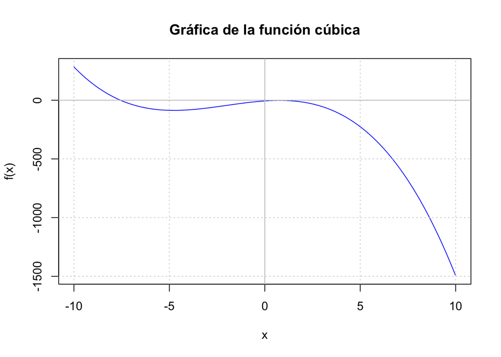

```r
plot(x, f_x, col="blue",
     type="l",
     main="Gráfica de la función cúbica",
     xlab = "x",
     ylab = "f(x)")
abline(v = 0, type="-", col="gray")
abline(h = 0, type="-", col="gray")
grid()
```

#### BUSQUEDA DE LA RAIZ

##### Búsqueda de la raíz en el intervalo $[-9,-5]$

Después de revisar la gráfica, seleccionamos el intervalo $[-9,-5]$

```r
a <- -9
b <- -5
```

##### Empezamos con el método de bisección: $c=\frac{a+b}{2}$

```r
c <- (a+b)/2;
print(c)
```

```
## [1] -7
```

##### Definimos la función f_cubica para evaluar en los puntos de interés

```r
f_cubica <- function(x){
  A*x^3+B*x^2+C*x+D
}
```

##### Evaluamos nuestra función en los puntos $a$, $b$ y $c$

```r
fa <- f_cubica(a); print(fa)
```

```
## [1] 138
```

```r
fb <- f_cubica(b); print(fb)
```

```
## [1] -86
```

```r
fc <- f_cubica(c); print(fc)
```

```
## [1] -34
```

##### Determinamos los signos de los productos

```r
signo_fafc <- sign(fa*fc); print(signo_fafc)
```

```
## [1] -1
```

```r
signo_fbfc <- sign(fb*fc); print(signo_fbfc)
```

```
## [1] 1
```

#### ITERACION 1

##### Primera iteración del método de bisección

Como $fa \cdot fc < 0$ hacemos la asignación $b \leftarrow c$, y calculamos el nuevo valor de $c$

```r
b <- c
c <- (a+b)/2; print(c)
```

```
## [1] -8
```

##### Evaluamos en el nuevo punto medio

```r
fa <- f_cubica(a); print(fa)
```

```
## [1] 138
```

```r
fb <- f_cubica(b); print(fb)
```

```
## [1] -34
```

```r
fc <- f_cubica(c); print(fc)
```

```
## [1] 34
```

##### Verificamos los signos

```r
signo_fafc <- sign(fa*fc); print(signo_fafc)
```

```
## [1] 1
```

```r
signo_fbfc <- sign(fb*fc); print(signo_fbfc)
```

```
## [1] -1
```

#### ITERACION 2

##### Segunda iteración del método de bisección

```r
if(signo_fafc < 0){
  b <- c
} else {
  a <- c
}
c <- (a+b)/2; print(c)
```

```
## [1] -7.5
```

##### Evaluamos en el nuevo punto medio

```r
fa <- f_cubica(a); print(fa)
```

```
## [1] 34
```

```r
fb <- f_cubica(b); print(fb)
```

```
## [1] -34
```

```r
fc <- f_cubica(c); print(fc)
```

```
## [1] -4.125
```

##### Verificamos los signos

```r
signo_fafc <- sign(fa*fc); print(signo_fafc)
```

```
## [1] -1
```

```r
signo_fbfc <- sign(fb*fc); print(signo_fbfc)
```

```
## [1] 1
```

#### ITERACION 3

##### Tercera iteración del método de bisección

```r
if(signo_fafc < 0){
  b <- c
} else {
  a <- c
}
c <- (a+b)/2; print(c)
```

```
## [1] -7.75
```

##### Evaluamos en el nuevo punto medio

```r
fa <- f_cubica(a); print(fa)
```

```
## [1] 34
```

```r
fb <- f_cubica(b); print(fb)
```

```
## [1] -4.125
```

```r
fc <- f_cubica(c); print(fc)
```

```
## [1] 13.85938
```

##### Verificamos los signos

```r
signo_fafc <- sign(fa*fc); print(signo_fafc)
```

```
## [1] 1
```

```r
signo_fbfc <- sign(fb*fc); print(signo_fbfc)
```

```
## [1] -1
```

#### METODO DE BISECCION COMPLETO

##### Implementación completa con tolerancia

```r
# Reiniciamos los valores iniciales
a <- -9
b <- -5
tol <- 1e-6
max_iter <- 100
iter <- 0

cat("Método de Bisección\n")
```

```
## Método de Bisección
```

```r
cat("Intervalo inicial: [", a, ",", b, "]\n")
```

```
## Intervalo inicial: [ -9 , -5 ]
```

```r
cat("Tolerancia:", tol, "\n\n")
```

```
## Tolerancia: 1e-06
```

```r
while((b - a)/2 > tol && iter < max_iter){
  iter <- iter + 1
  c <- (a + b)/2
  fa <- f_cubica(a)
  fb <- f_cubica(b)
  fc <- f_cubica(c)

  cat(sprintf("Iteración %d: c = %.8f, f(c) = %.8f, intervalo = [%.8f, %.8f]\n",
              iter, c, fc, a, b))

  if(abs(fc) < tol){
    cat("\nRaíz encontrada por criterio de función\n")
    break
  }

  if(sign(fa * fc) < 0){
    b <- c
  } else {
    a <- c
  }
}
```

```
## Iteración 1: c = -7.00000000, f(c) = -34.00000000, intervalo = [-9.00000000, -5.00000000]
## Iteración 2: c = -8.00000000, f(c) = 34.00000000, intervalo = [-9.00000000, -7.00000000]
## Iteración 3: c = -7.50000000, f(c) = -4.12500000, intervalo = [-8.00000000, -7.00000000]
## Iteración 4: c = -7.75000000, f(c) = 13.85937500, intervalo = [-8.00000000, -7.50000000]
## Iteración 5: c = -7.62500000, f(c) = 4.60351562, intervalo = [-7.75000000, -7.50000000]
## Iteración 6: c = -7.56250000, f(c) = 0.17407227, intervalo = [-7.62500000, -7.50000000]
## Iteración 7: c = -7.53125000, f(c) = -1.99166870, intervalo = [-7.56250000, -7.50000000]
## Iteración 8: c = -7.54687500, f(c) = -0.91286087, intervalo = [-7.56250000, -7.53125000]
## Iteración 9: c = -7.55468750, f(c) = -0.37041140, intervalo = [-7.56250000, -7.54687500]
## Iteración 10: c = -7.55859375, f(c) = -0.09842402, intervalo = [-7.56250000, -7.55468750]
## Iteración 11: c = -7.56054688, f(c) = 0.03776049, intervalo = [-7.56250000, -7.55859375]
## Iteración 12: c = -7.55957031, f(c) = -0.03034767, intervalo = [-7.56054688, -7.55859375]
## Iteración 13: c = -7.56005859, f(c) = 0.00370243, intervalo = [-7.56054688, -7.55957031]
## Iteración 14: c = -7.55981445, f(c) = -0.01332361, intervalo = [-7.56005859, -7.55957031]
## Iteración 15: c = -7.55993652, f(c) = -0.00481084, intervalo = [-7.56005859, -7.55981445]
## Iteración 16: c = -7.55999756, f(c) = -0.00055427, intervalo = [-7.56005859, -7.55993652]
## Iteración 17: c = -7.56002808, f(c) = 0.00157407, intervalo = [-7.56005859, -7.55999756]
## Iteración 18: c = -7.56001282, f(c) = 0.00050990, intervalo = [-7.56002808, -7.55999756]
## Iteración 19: c = -7.56000519, f(c) = -0.00002219, intervalo = [-7.56001282, -7.55999756]
## Iteración 20: c = -7.56000900, f(c) = 0.00024386, intervalo = [-7.56001282, -7.56000519]
## Iteración 21: c = -7.56000710, f(c) = 0.00011084, intervalo = [-7.56000900, -7.56000519]
```

```r
cat("\nRaíz aproximada:", c, "\n")
```

```
##
## Raíz aproximada: -7.560007
```

```r
cat("f(raíz) =", f_cubica(c), "\n")
```

```
## f(raíz) = 0.0001108353
```

```r
cat("Número de iteraciones:", iter, "\n")
```

```
## Número de iteraciones: 21
```

```r
cat("Longitud del intervalo final:", (b-a), "\n")
```

```
## Longitud del intervalo final: 1.907349e-06
```

#### VISUALIZACION DE LA RAIZ ENCONTRADA

##### Gráfica con la raíz marcada

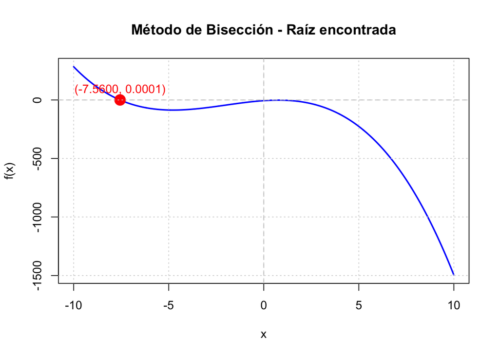

```r
x_plot <- seq(-10, 10, 0.01)
f_plot <- A*x_plot^3 + B*x_plot^2 + C*x_plot + D

plot(x_plot, f_plot, col="blue", type="l",
     main="Método de Bisección - Raíz encontrada",
     xlab = "x", ylab = "f(x)", lwd=2)
abline(v = 0, col="gray", lty=2)
abline(h = 0, col="gray", lty=2)
points(c, f_cubica(c), col="red", pch=19, cex=2)
text(c, f_cubica(c), labels=sprintf("(%.4f, %.4f)", c, f_cubica(c)),
     pos=3, col="red")
grid()
```

### Practica del dia 22

#### METODO DE LA SECANTE

##### Ejemplo 1

###### Gráfica de la función $f(x)=2x^{3}-3x^{2}-11x+6$

Graficamos la función $f(x)=2x^{3}-3x^{2}-11x+6$ en el intervalo $[-10,10]$

```r
N <- 0.01
a <- -10
b <- 10
x <- seq(a, b, N)
head(x, 10)
```

```
##  [1] -10.00  -9.99  -9.98  -9.97  -9.96  -9.95  -9.94  -9.93  -9.92  -9.91
```

###### Evaluación de la función cúbica

```r
A <- 2
B <- -3
C <- -11
D <- 6
f_x <- A*x^3 + B*x^2 + C*x + D
paste(head(f_x, 10))
```

```
##  [1] "-2184"        "-2177.516298" "-2171.045184" "-2164.586646" "-2158.140672"
##  [6] "-2151.70725"  "-2145.286368" "-2138.878014" "-2132.482176" "-2126.098842"
```

###### Graficamos la función

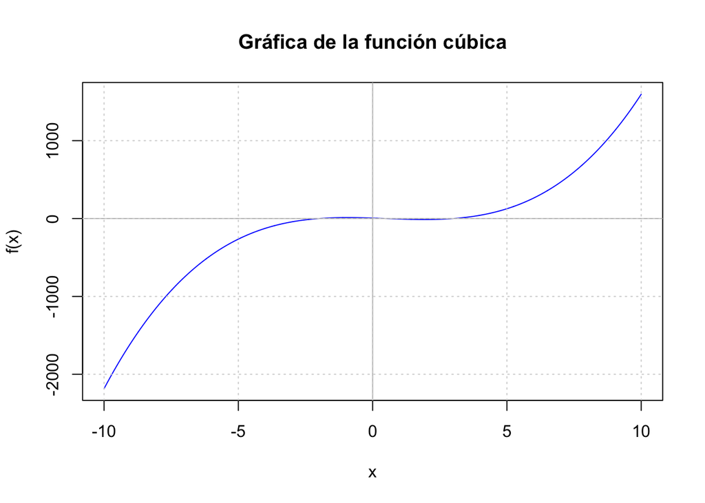

```r
plot(x, f_x, col="blue",
     type = "l",
     main="Gráfica de la función cúbica",
     xlab = "x",
     ylab = "f(x)")
abline(v = 0, type = "-", col = "gray")
abline(h = 0, type = "-", col = "gray")
grid()
```

#### DEFINICION DE LA FUNCION SECANTE

##### Función del método de la secante

La fórmula del método de la secante es:
$$x_{k+1} = x_k - \frac{f(x_k)(x_k -
x_{k-1})}{f(x_k) - f(x_{k-1})}$$

```r
f_secante <- function(x0, x1){
  A <- 2; B <- -3; C <- -11; D <- 6
  fx0 <- A*x0^3 + B*x0^2 + C*x0 + D
  fx1 <- A*x1^3 + B*x1^2 + C*x1 + D
  x2 <- x1 - (fx1*(x1-x0)/(fx1-fx0))
  list(next_x = x2, fx0 = fx0, fx1 = fx1)
}
```

###### Prueba inicial de la función

```r
r <- f_secante(0, 3)
(r)
```

```
## $next_x
## [1] 3
##
## $fx0
## [1] 6
##
## $fx1
## [1] 0
```

#### ITERACIONES DEL METODO DE LA SECANTE

##### Iteración 0: Valores iniciales

```r
x0 <- 2.5
x1 <- 3.5
cat("x0 =", x0, "\n")
```

```
## x0 = 2.5
```

```r
cat("x1 =", x1, "\n")
```

```
## x1 = 3.5
```

##### Iteración 1

```r
r <- f_secante(x0, x1)
x2 <- r$next_x
fx2 <- A*x2^3 + B*x2^2 + C*x2 + D
mi_error <- abs(x2 - x1)

cat("x2 =", x2, "\n")
```

```
## x2 = 2.852941
```

```r
cat("f(x2) =", fx2, "\n")
```

```
## f(x2) = -3.358437
```

```r
cat("Error =", mi_error, "\n")
```

```
## Error = 0.6470588
```

##### Iteración 2

```r
x0 <- x1
x1 <- x2
r <- f_secante(x0, x1)
x3 <- r$next_x
fx3 <- A*x3^3 + B*x3^2 + C*x3 + D
mi_error <- abs(x3 - x2)

cat("x3 =", x3, "\n")
```

```
## x3 = 2.962371
```

```r
cat("f(x3) =", fx3, "\n")
```

```
## f(x3) = -0.9195913
```

```r
cat("Error =", mi_error, "\n")
```

```
## Error = 0.1094299
```

##### Iteración 3

```r
x0 <- x2
x1 <- x3
r <- f_secante(x0, x1)
x4 <- r$next_x
fx4 <- A*x4^3 + B*x4^2 + C*x4 + D
mi_error <- abs(x4 - x3)

cat("x4 =", x4, "\n")
```

```
## x4 = 3.003633
```

```r
cat("f(x4) =", fx4, "\n")
```

```
## f(x4) = 0.09101516
```

```r
cat("Error =", mi_error, "\n")
```

```
## Error = 0.04126164
```

##### Iteración 4

```r
x0 <- x3
x1 <- x4
r <- f_secante(x0, x1)
x5 <- r$next_x
fx5 <- A*x5^3 + B*x5^2 + C*x5 + D
mi_error <- abs(x5 - x4)

cat("x5 =", x5, "\n")
```

```
## x5 = 2.999917
```

```r
cat("f(x5) =", fx5, "\n")
```

```
## f(x5) = -0.002083295
```

```r
cat("Error =", mi_error, "\n")
```

```
## Error = 0.00371602
```

##### Iteración 5

```r
x0 <- x4
x1 <- x5
r <- f_secante(x0, x1)
x6 <- r$next_x
fx6 <- A*x6^3 + B*x6^2 + C*x6 + D
mi_error <- abs(x6 - x5)

cat("x6 =", x6, "\n")
```

```
## x6 = 3
```

```r
cat("f(x6) =", fx6, "\n")
```

```
## f(x6) = -4.533488e-06
```

```r
cat("Error =", mi_error, "\n")
```

```
## Error = 8.315461e-05
```

##### Iteración 6

```r
x0 <- x5
x1 <- x6
r <- f_secante(x0, x1)
x7 <- r$next_x
fx7 <- A*x7^3 + B*x7^2 + C*x7 + D
mi_error <- abs(x7 - x6)

cat("x7 =", x7, "\n")
```

```
## x7 = 3
```

```r
cat("f(x7) =", fx7, "\n")
```

```
## f(x7) = 2.266916e-10
```

```r
cat("Error =", mi_error, "\n")
```

```
## Error = 1.813486e-07
```

#### IMPLEMENTACION COMPLETA DEL METODO

##### Método de la secante con tolerancia

```r
metodo_secante <- function(x0, x1, tol = 1e-6, max_iter = 100){
  A <- 2; B <- -3; C <- -11; D <- 6
  f <- function(x) A*x^3 + B*x^2 + C*x + D

  iteraciones <- data.frame(
    k = integer(),
    x_k = numeric(),
    f_xk = numeric(),
    error = numeric()
  )

  cat("Método de la Secante\n")
  cat("x0 =", x0, ", f(x0) =", f(x0), "\n")
  cat("x1 =", x1, ", f(x1) =", f(x1), "\n")
  cat("Tolerancia:", tol, "\n\n")

  iteraciones <- rbind(iteraciones, data.frame(k=0, x_k=x0, f_xk=f(x0), error=NA))
  iteraciones <- rbind(iteraciones, data.frame(k=1, x_k=x1, f_xk=f(x1), error=abs(x1-x0)))

  for(k in 2:max_iter){
    fx0 <- f(x0)
    fx1 <- f(x1)

    if(abs(fx1 - fx0) < 1e-12){
      cat("División por cero inminente. Método detenido.\n")
      break
    }

    x2 <- x1 - fx1*(x1 - x0)/(fx1 - fx0)
    fx2 <- f(x2)
    error <- abs(x2 - x1)

    iteraciones <- rbind(iteraciones, data.frame(k=k, x_k=x2, f_xk=fx2, error=error))

    cat(sprintf("k=%d: x = %.10f, f(x) = %.10e, error = %.10e\n", k, x2, fx2, error))

    if(error < tol || abs(fx2) < tol){
      cat("\nConvergencia alcanzada!\n")
      break
    }

    x0 <- x1
    x1 <- x2
  }

  return(list(raiz = x2, iteraciones = iteraciones, num_iter = k))
}

resultado <- metodo_secante(2.5, 3.5)
```

```
## Método de la Secante
## x0 = 2.5 , f(x0) = -9
## x1 = 3.5 , f(x1) = 16.5
## Tolerancia: 1e-06
##
## k=2: x = 2.8529411765, f(x) = -3.3584368003e+00, error = 6.4705882353e-01
## k=3: x = 2.9623710468, f(x) = -9.1959131766e-01, error = 1.0942987038e-01
## k=4: x = 3.0036326845, f(x) = 9.1015155248e-02, error = 4.1261637691e-02
## k=5: x = 2.9999166640, f(x) = -2.0832946501e-03, error = 3.7160204896e-03
## k=6: x = 2.9999998187, f(x) = -4.5334876901e-06, error = 8.3154613358e-05
## k=7: x = 3.0000000000, f(x) = 2.2669155442e-10, error = 1.8134859481e-07
##
## Convergencia alcanzada!
```

##### Tabla de iteraciones

```r
print(resultado$iteraciones)
```

```
##   k      x_k          f_xk        error
## 1 0 2.500000 -9.000000e+00           NA
## 2 1 3.500000  1.650000e+01 1.000000e+00
## 3 2 2.852941 -3.358437e+00 6.470588e-01
## 4 3 2.962371 -9.195913e-01 1.094299e-01
## 5 4 3.003633  9.101516e-02 4.126164e-02
## 6 5 2.999917 -2.083295e-03 3.716020e-03
## 7 6 3.000000 -4.533488e-06 8.315461e-05
## 8 7 3.000000  2.266916e-10 1.813486e-07
```

##### Resultados finales

```r
cat("\nRaíz aproximada:", resultado$raiz, "\n")
```

```
##
## Raíz aproximada: 3
```

```r
cat("Número de iteraciones:", resultado$num_iter, "\n")
```

```
## Número de iteraciones: 7
```

```r
cat("f(raíz) =", A*resultado$raiz^3 + B*resultado$raiz^2 + C*resultado$raiz + D, "\n")
```

```
## f(raíz) = 2.266916e-10
```

#### VISUALIZACION DEL METODO

##### Gráfica con la raíz encontrada

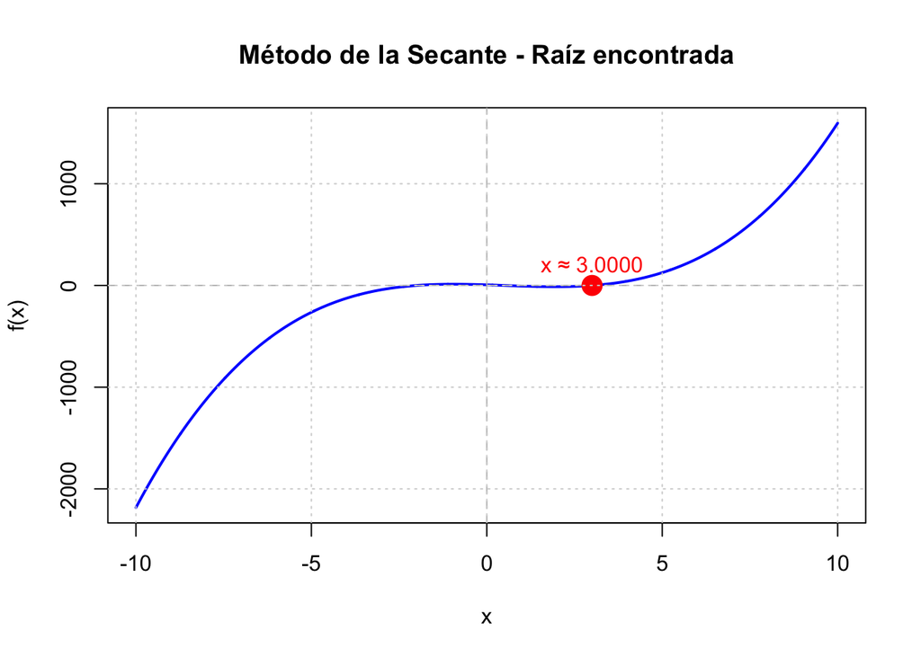

```r
x_plot <- seq(-10, 10, 0.01)
f_plot <- A*x_plot^3 + B*x_plot^2 + C*x_plot + D

plot(x_plot, f_plot, col="blue", type="l",
     main="Método de la Secante - Raíz encontrada",
     xlab = "x", ylab = "f(x)", lwd=2)
abline(v = 0, col="gray", lty=2)
abline(h = 0, col="gray", lty=2)
points(resultado$raiz, 0, col="red", pch=19, cex=2)
text(resultado$raiz, 0,
     labels=sprintf("x ≈ %.4f", resultado$raiz),
     pos=3, col="red")
grid()
```

#### COMPARACION DE CONVERGENCIA

##### Gráfica del error en cada iteración

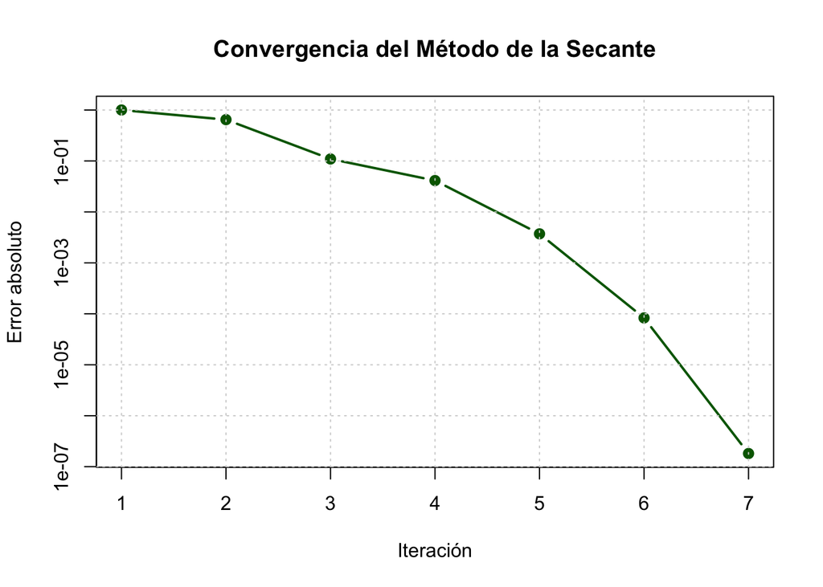

```r
iter_data <- resultado$iteraciones[-1,]  # Excluir k=0 que tiene error NA

plot(iter_data$k, iter_data$error,
     type="b", col="darkgreen", pch=19,
     main="Convergencia del Método de la Secante",
     xlab="Iteración", ylab="Error absoluto",
     log="y", lwd=2)
grid()
```

## Noviembre

### Practica del dia 5 (Ultima clase en teoria)

#### INTERPOLACION POLINOMIAL

##### Primer paso: graficamos los puntos

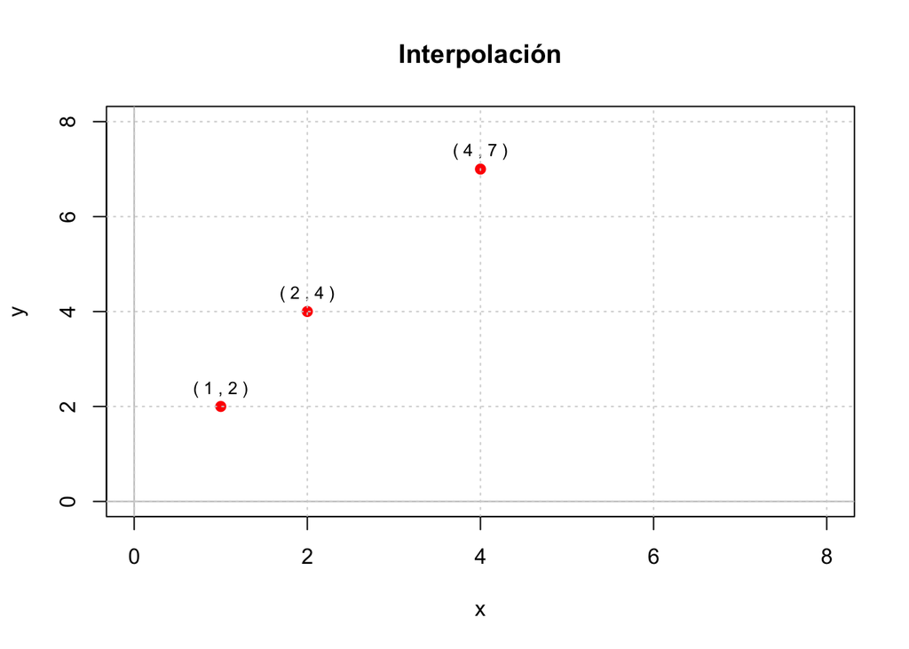

```r
x <- c(1, 2, 4)
y <- c(2, 4, 7)
plot(x, y, type = "p", pch = 19, col = "red",
     main = "Interpolación",
     xlab = "x",
     ylab = "y",
     xlim = c(0, 8),
     ylim = c(0, 8))
text(x, y, labels = paste("(", x, ",", y, ")"), pos = 3, cex = 0.8)
abline(v = 0, type = "-", col = "gray")
abline(h = 0, type = "-", col = "gray")
grid()
```

#### SISTEMA DE ECUACIONES PARA INTERPOLACION

##### Definición de la matriz A y vector b

Para encontrar el polinomio $P(x) = a_0 + a_1x + a_2x^2$ que pasa por los puntos $(1,2)$, $(2,4)$ y $(4,7)$

```r
A <- matrix(c(
  1, 1, 1,
  1, 2, 4,
  1, 4, 16), nrow = 3, byrow = TRUE)
b <- c(2, 4, 7);
print(A)
```

```
##      [,1] [,2] [,3]
## [1,]    1    1    1
## [2,]    1    2    4
## [3,]    1    4   16
```

```r
print(b)
```

```
## [1] 2 4 7
```

##### Crear matriz aumentada

```r
Ab <- cbind(A, b)
print(Ab)
```

```
##             b
## [1,] 1 1  1 2
## [2,] 1 2  4 4
## [3,] 1 4 16 7
```

#### ELIMINACION GAUSSIANA

##### Paso 1: Eliminar debajo del pivote [1,1]

Eliminación Gaussiana Simple - Primera columna

```r
m1 <- -Ab[2,1]/Ab[1,1]; (m1)
```

```
##
## -1
```

```r
m2 <- -Ab[3,1]/Ab[1,1]; (m2)
```

```
##
## -1
```

```r
A1 <- Ab[1,]; (A1)
```

```
##       b
## 1 1 1 2
```

```r
A2 <- m1*Ab[1,]+Ab[2,]; (A2)
```

```
##       b
## 0 1 3 2
```

```r
A3 <- m2*Ab[1,]+Ab[3,]; (A3)
```

```
##           b
##  0  3 15  5
```

```r
NuevaA <- rbind(A1,A2,A3); (NuevaA)
```

```
##           b
## A1 1 1  1 2
## A2 0 1  3 2
## A3 0 3 15 5
```

##### Paso 2: Eliminar debajo del pivote [2,2]

Segunda columna

```r
Ab <- NuevaA
m3 <- -Ab[3,2]/Ab[2,2]; (m3)
```

```
## [1] -3
```

```r
A1 <- Ab[1,]
A2 <- Ab[2,]
A3 <- m3*Ab[2,]+Ab[3,]; (A3)
```

```
##           b
##  0  0  6 -1
```

```r
NuevaA <- rbind(A1,A2,A3); (NuevaA)
```

```
##           b
## A1 1 1 1  2
## A2 0 1 3  2
## A3 0 0 6 -1
```

##### Paso 3: Sustitución hacia atrás

Eliminar arriba del pivote [3,3]

```r
Ab <- NuevaA
m4 <- -Ab[2,3]/Ab[3,3]; (m4)
```

```
## [1] -0.5
```

```r
m5 <- -Ab[1,3]/Ab[3,3]; (m5)
```

```
## [1] -0.1666667
```

```r
A1 <- m5*Ab[3,]+Ab[1,]; (A1)
```

```
##                                   b
## 1.000000 1.000000 0.000000 2.166667
```

```r
A2 <- m4*Ab[3,]+Ab[2,]; (A2)
```

```
##               b
## 0.0 1.0 0.0 2.5
```

```r
A3 <- Ab[3,]
NuevaA <- rbind(A1,A2,A3); (NuevaA)
```

```
##                  b
## A1 1 1 0  2.166667
## A2 0 1 0  2.500000
## A3 0 0 6 -1.000000
```

##### Eliminar arriba del pivote [2,2]

```r
Ab <- NuevaA
m6 <- -Ab[1,2]/Ab[2,2]; (m6)
```

```
## [1] -1
```

```r
A1 <- m6*Ab[2,]+Ab[1,]; (A1)
```

```
##                                           b
##  1.0000000  0.0000000  0.0000000 -0.3333333
```

```r
A2 <- Ab[2,]
A3 <- Ab[3,]
NuevaA <- rbind(A1,A2,A3); (NuevaA)
```

```
##                   b
## A1 1 0 0 -0.3333333
## A2 0 1 0  2.5000000
## A3 0 0 6 -1.0000000
```

#### SOLUCION DEL SISTEMA

##### Obtención de los coeficientes del polinomio

```r
a0 <- NuevaA[1,4] / NuevaA[1,1]
a1 <- NuevaA[2,4] / NuevaA[2,2]
a2 <- NuevaA[3,4] / NuevaA[3,3]

cat("Coeficientes del polinomio interpolante:\n")
```

```
## Coeficientes del polinomio interpolante:
```

```r
cat("a0 =", a0, "\n")
```

```
## a0 = -0.3333333
```

```r
cat("a1 =", a1, "\n")
```

```
## a1 = 2.5
```

```r
cat("a2 =", a2, "\n")
```

```
## a2 = -0.1666667
```

```r
cat("\nPolinomio: P(x) =", a0, "+", a1, "x +", a2, "x²\n")
```

```
##
## Polinomio: P(x) = -0.3333333 + 2.5 x + -0.1666667 x²
```

##### Verificación del sistema

```r
solucion <- c(a0, a1, a2)
resultado <- A %*% solucion
cat("Verificación A*x = b:\n")
```

```
## Verificación A*x = b:
```

```r
print(resultado)
```

```
##      [,1]
## [1,]    2
## [2,]    4
## [3,]    7
```

```r
cat("\nVector b original:\n")
```

```
##
## Vector b original:
```

```r
print(b)
```

```
## [1] 2 4 7
```

```r
cat("\nDiferencia:\n")
```

```
##
## Diferencia:
```

```r
print(abs(resultado - b))
```

```
##              [,1]
## [1,] 2.220446e-16
## [2,] 4.440892e-16
## [3,] 0.000000e+00
```

#### GRAFICACION DEL POLINOMIO INTERPOLANTE

##### Gráfica del polinomio con los puntos originales

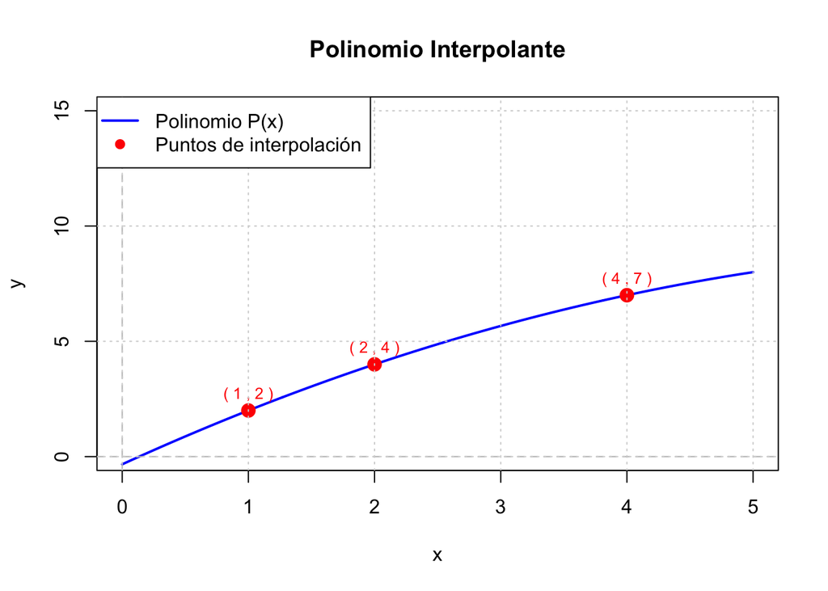

```r
# Definimos el polinomio interpolante
P <- function(x) {
  a0 + a1*x + a2*x^2
}

# Creamos valores para graficar
x_vals <- seq(0, 5, 0.01)
y_vals <- P(x_vals)

# Graficamos
plot(x_vals, y_vals, type = "l", col = "blue", lwd = 2,
     main = "Polinomio Interpolante",
     xlab = "x",
     ylab = "y",
     xlim = c(0, 5),
     ylim = c(0, 15))
points(x, y, pch = 19, col = "red", cex = 1.5)
text(x, y, labels = paste("(", x, ",", y, ")"), pos = 3, cex = 0.8, col = "red")
abline(v = 0, col = "gray", lty = 2)
abline(h = 0, col = "gray", lty = 2)
grid()
legend("topleft",
       legend = c("Polinomio P(x)", "Puntos de interpolación"),
       col = c("blue", "red"),
       lwd = c(2, NA),
       pch = c(NA, 19))
```

#### EVALUACION DEL POLINOMIO

##### Evaluación en puntos intermedios

```r
# Evaluamos el polinomio en algunos puntos
puntos_eval <- c(1.5, 2.5, 3, 3.5)
valores_eval <- P(puntos_eval)

cat("Evaluación del polinomio interpolante:\n")
```

```
## Evaluación del polinomio interpolante:
```

```r
for(i in 1:length(puntos_eval)){
  cat(sprintf("P(%.1f) = %.4f\n", puntos_eval[i], valores_eval[i]))
}
```

```
## P(1.5) = 3.0417
## P(2.5) = 4.8750
## P(3.0) = 5.6667
## P(3.5) = 6.3750
```

##### Verificación en los puntos originales

```r
cat("\nVerificación en puntos originales:\n")
```

```
##
## Verificación en puntos originales:
```

```r
for(i in 1:length(x)){
  cat(sprintf("P(%d) = %.4f (esperado: %d)\n", x[i], P(x[i]), y[i]))
}
```

```
## P(1) = 2.0000 (esperado: 2)
## P(2) = 4.0000 (esperado: 4)
## P(4) = 7.0000 (esperado: 7)
```

#### COMPARACION CON METODOS DE R

##### Usando la función poly de R

```r
# Comparación con el método de R
modelo <- lm(y ~ poly(x, 2, raw = TRUE))
coef_R <- coef(modelo)

cat("Coeficientes obtenidos con lm() de R:\n")
```

```
## Coeficientes obtenidos con lm() de R:
```

```r
cat("a0 =", coef_R[1], "\n")
```

```
## a0 = -0.3333333
```

```r
cat("a1 =", coef_R[2], "\n")
```

```
## a1 = 2.5
```

```r
cat("a2 =", coef_R[3], "\n")
```

```
## a2 = -0.1666667
```

```r
cat("\nNuestros coeficientes:\n")
```

```
##
## Nuestros coeficientes:
```

```r
cat("a0 =", a0, "\n")
```

```
## a0 = -0.3333333
```

```r
cat("a1 =", a1, "\n")
```

```
## a1 = 2.5
```

```r
cat("a2 =", a2, "\n")
```

```
## a2 = -0.1666667
```

```r
cat("\nDiferencia:\n")
```

```
##
## Diferencia:
```

```r
cat("Δa0 =", abs(coef_R[1] - a0), "\n")
```

```
## Δa0 = 1.665335e-15
```

```r
cat("Δa1 =", abs(coef_R[2] - a1), "\n")
```

```
## Δa1 = 1.332268e-15
```

```r
cat("Δa2 =", abs(coef_R[3] - a2), "\n")
```

```
## Δa2 = 1.94289e-16
```

#### INTERPOLACION CON MAS PUNTOS

##### Ejemplo con 5 puntos

```r
# Nuevos puntos
x_new <- c(1, 2, 3, 4, 5)
y_new <- c(2, 4, 5, 7, 11)

# Matriz de Vandermonde para polinomio de grado 4
A_new <- matrix(c(
  1, 1,  1,  1,   1,
  1, 2,  4,  8,  16,
  1, 3,  9, 27,  81,
  1, 4, 16, 64, 256,
  1, 5, 25, 125, 625
), nrow = 5, byrow = TRUE)

# Resolver usando solve()
coefs_new <- solve(A_new, y_new)

cat("Coeficientes del polinomio de grado 4:\n")
```

```
## Coeficientes del polinomio de grado 4:
```

```r
for(i in 1:length(coefs_new)){
  cat(sprintf("a%d = %.6f\n", i-1, coefs_new[i]))
}
```

```
## a0 = -4.000000
## a1 = 9.250000
## a2 = -3.958333
## a3 = 0.750000
## a4 = -0.041667
```

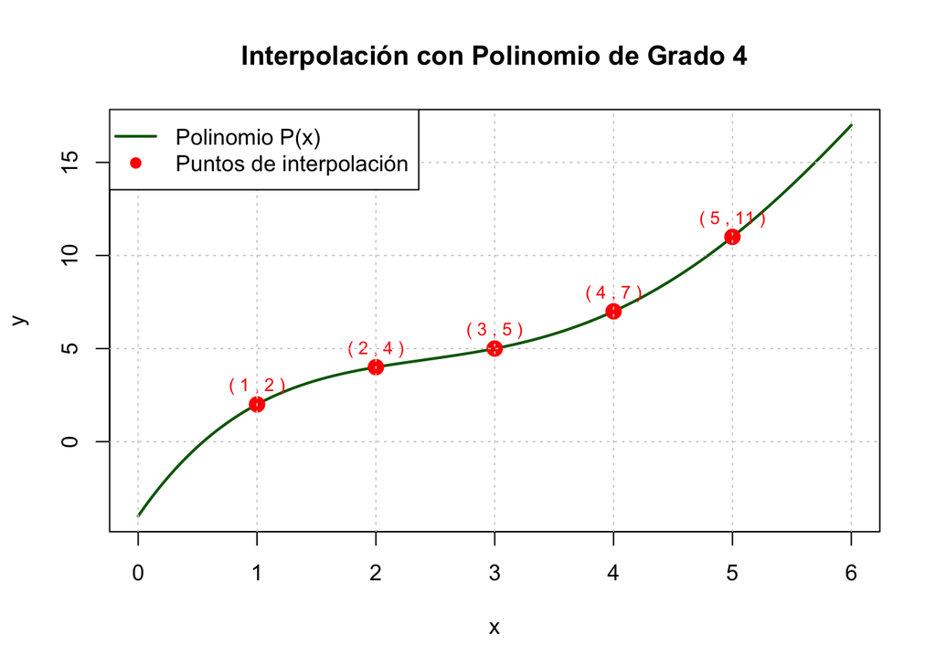

```r
# Definir y graficar el nuevo polinomio
P_new <- function(x) {
  coefs_new[1] + coefs_new[2]*x + coefs_new[3]*x^2 +
    coefs_new[4]*x^3 + coefs_new[5]*x^4
}

x_plot <- seq(0, 6, 0.01)
y_plot <- P_new(x_plot)

plot(x_plot, y_plot, type = "l", col = "darkgreen", lwd = 2,
     main = "Interpolación con Polinomio de Grado 4",
     xlab = "x", ylab = "y")
points(x_new, y_new, pch = 19, col = "red", cex = 1.5)
text(x_new, y_new, labels = paste("(", x_new, ",", y_new, ")"),
     pos = 3, cex = 0.8, col = "red")
grid()
legend("topleft",
       legend = c("Polinomio P(x)", "Puntos de interpolación"),
       col = c("darkgreen", "red"),
       lwd = c(2, NA),
       pch = c(NA, 19))
```

# Revisión de Programas

## Métodos de Eliminación Directa

### Gaussiana Simple

```r
gauss_simple <- function(A, b, tolerancia, verbose = FALSE) {
  if (!is.matrix(A)) stop("A debe ser una matriz.")
  if (!is.numeric(b)) stop("b debe ser numérico.")
  n <- nrow(A)
  if (ncol(A) != n) stop("A debe ser cuadrada.")
  if (length(b) != n) stop("Longitud de b debe ser igual al número de filas de A.")

  Ab <- cbind(A, b)
  numcols = ncol(Ab)

  for (k in 1:(n-1)) {
    pivote <- Ab[k, k]
    if (abs(pivote) < tolerancia) {
      stop(sprintf("Pivote casi cero en fila %d (%.3e). El método sin pivoteo falla.", k, pivote))
    }
    if (k + 1 <= n) {
      for (i in (k + 1):n) {
        m <- Ab[i, k] / pivote
        Ab[i, k:numcols] <- Ab[i, k:numcols] - m * Ab[k, k:numcols]
        if (abs(Ab[i, k]) < tolerancia) Ab[i, k] <- 0
        if (verbose) {
          cat(sprintf("k=%d, i=%d, m=%.6g\n", k, i, m))
          print(Ab)
        }
      }
    }
  }

  x <- numeric(n)
  for (i in n:1) {
    if (i == n) {
      suma <- 0
    } else {
      suma <- sum(Ab[i, (i + 1):n] * x[(i + 1):n])
    }
    x[i] <- (Ab[i, n + 1] - suma) / Ab[i, i]
  }

  list(x=x, U=Ab[, 1:n], Ab=Ab)
}
```

#### Ejemplo

```r
A <- matrix(c(
  2, 1, -1,
  -3, -1, 2,
  -2, 1, 2
), nrow = 3, byrow = TRUE)

b <- c(8, -11, -3)
tolerancia <- 1e-12

res <- gauss_simple(A, b, tolerancia)
res <- gauss_simple(A, b, tolerancia, verbose = TRUE)
```

```
## k=1, i=2, m=-1.5
##                   b
## [1,]  2 1.0 -1.0  8
## [2,]  0 0.5  0.5  1
## [3,] -2 1.0  2.0 -3
## k=1, i=3, m=-1
##                 b
## [1,] 2 1.0 -1.0 8
## [2,] 0 0.5  0.5 1
## [3,] 0 2.0  1.0 5
## k=2, i=3, m=4
##                 b
## [1,] 2 1.0 -1.0 8
## [2,] 0 0.5  0.5 1
## [3,] 0 0.0 -1.0 1
```

```r
res$x
```

```
## [1]  2  3 -1
```

```r
res$U
```

```
##
## [1,] 2 1.0 -1.0
## [2,] 0 0.5  0.5
## [3,] 0 0.0 -1.0
```

```r
res$Ab
```

```
##                 b
## [1,] 2 1.0 -1.0 8
## [2,] 0 0.5  0.5 1
## [3,] 0 0.0 -1.0 1
```

```r
A %*% res$x
```

```
##      [,1]
## [1,]    8
## [2,]  -11
## [3,]   -3
```

### Gaussiana con Pivoteo Parcial

```r
gauss_piv_parcial <- function(A, b, tolerancia, verbose = FALSE) {
  if (!is.matrix(A)) stop("A debe ser una matriz.")
  n <- nrow(A)
  if (ncol(A) != n) stop("A debe ser cuadrada.")
  if (length(b) != n) stop("Dimensiones de b incorrectas.")

  Ab <- cbind(A, b)

  for (k in 1:(n-1)) {
    # Selección del pivote (máximo en valor absoluto en la columna k desde la fila k)
    max_row <- which.max(abs(Ab[k:n, k])) + (k-1)
    if (abs(Ab[max_row, k]) < tolerancia) {
      stop(sprintf("Pivote casi nulo en columna %d", k))
    }

    # Intercambio de filas si es necesario
    if (max_row != k) {
      Ab[c(k, max_row), ] <- Ab[c(max_row, k), ]
      if (verbose) {
        cat(sprintf("Intercambio de fila %d con fila %d\n", k, max_row))
        print(Ab)
      }
    }

    for (i in (k + 1):n) {
      m <- Ab[i, k] / Ab[k, k]
      Ab[i, k:ncol(Ab)] <- Ab[i, k:ncol(Ab)] - m * Ab[k, k:ncol(Ab)]
      if (abs(Ab[i, k]) < tolerancia) Ab[i, k] <- 0
      if (verbose) {
        cat(sprintf("k=%d, i=%d, m=%.6g\n", k, i, m))
        print(Ab)
      }
    }
  }

  x <- numeric(n)
  for (i in n:1) {
    if (i == n) {
      suma <- 0
    } else {
      suma <- sum(Ab[i, (i + 1):n] * x[(i + 1):n])
    }
    x[i] <- (Ab[i, n + 1] - suma) / Ab[i, i]
  }

  list(x = x, U = Ab[, 1:n], Ab = Ab)
}
```

#### Ejemplo

```r
A <- matrix(c(
  0, 2, 1,
  1, -2, -3,
  -1, 1, 2
), nrow = 3, byrow = TRUE)

b <- c(3, -3, -1)
tolerancia <- 1e-12

res <- gauss_piv_parcial(A, b, tolerancia, verbose = TRUE)
```

```
## Intercambio de fila 1 con fila 2
##                b
## [1,]  1 -2 -3 -3
## [2,]  0  2  1  3
## [3,] -1  1  2 -1
## k=1, i=2, m=0
##                b
## [1,]  1 -2 -3 -3
## [2,]  0  2  1  3
## [3,] -1  1  2 -1
## k=1, i=3, m=-1
##               b
## [1,] 1 -2 -3 -3
## [2,] 0  2  1  3
## [3,] 0 -1 -1 -4
## k=2, i=3, m=-0.5
##                   b
## [1,] 1 -2 -3.0 -3.0
## [2,] 0  2  1.0  3.0
## [3,] 0  0 -0.5 -2.5
```

```r
res$x
```

```
## [1] 10 -1  5
```

### Gauss Jordan

```r
gauss_jordan <- function(A, b, tolerancia, verbose = FALSE) {
  if (!is.matrix(A)) stop("A debe ser una matriz.")
  n <- nrow(A)
  m <- ncol(A)
  if (!is.null(b) && length(b) != n)
    stop("Dimensiones incompatibles entre A y b.")

  Ab <- cbind(A, as.matrix(b))
  ncols <- ncol(Ab)
  row <- 1

  for (col in 1:m) {
    if (row > n) break

    pivot_row_rel <- which.max(abs(Ab[row:n, col]))
    pivot_row <- row + pivot_row_rel - 1

    if (abs(Ab[pivot_row, col]) < tolerancia) {
      if (verbose) cat(sprintf("Sin pivote usable en col=%d (|piv| <tol). Se omite columna.\n", col))
      next
    }

    if (pivot_row != row) {
      Ab[c(row, pivot_row), ] <- Ab[c(pivot_row, row), ]
      if (verbose) {
        cat(sprintf("Swap filas %d <-> %d (col=%d)\n", row, pivot_row, col))
        print(Ab)
      }
    }

    pivote <- Ab[row, col]
    Ab[row, ] <- Ab[row, ] / pivote
    if (verbose) {
      cat(sprintf("Normaliza fila %d por pivote %.6g (col=%d)\n", row, pivote, col))
      print(Ab)
    }

    for (r in 1:n) {
      if (r == row) next
      factor <- Ab[r, col]
      if (abs(factor) > tolerancia) {
        Ab[r, ] <- Ab[r, ] - factor * Ab[row, ]
        if (verbose) {
          cat(sprintf("R%d := R%d - (%.6g)*R%d (col=%d)\n", r, r, factor, row, col))
          print(Ab)
        }
      }
    }
    row <- row + 1
  }

  Ab[abs(Ab) < tolerancia] <- 0
  out <- list(RREF = Ab)
  X <- Ab[, (m + 1):ncols, drop = FALSE]
  out$x <- if (ncol(X) == 1) as.vector(X) else X
  return(out)
}
```

#### Ejemplo

```r
A <- matrix(c(
  2, 1, -1,
  -3, -1, 2,
  -2, 1, 2
), nrow = 3, byrow = TRUE)

b <- c(8, -11, -3)
tolerancia <- 1e-12

res <- gauss_jordan(A, b, tolerancia, verbose = TRUE)
```

```
## Swap filas 1 <-> 2 (col=1)
##      [,1] [,2] [,3] [,4]
## [1,]   -3   -1    2  -11
## [2,]    2    1   -1    8
## [3,]   -2    1    2   -3
## Normaliza fila 1 por pivote -3 (col=1)
##      [,1]      [,2]       [,3]      [,4]
## [1,]    1 0.3333333 -0.6666667  3.666667
## [2,]    2 1.0000000 -1.0000000  8.000000
## [3,]   -2 1.0000000  2.0000000 -3.000000
## R2 := R2 - (2)*R1 (col=1)
##      [,1]      [,2]       [,3]       [,4]
## [1,]    1 0.3333333 -0.6666667  3.6666667
## [2,]    0 0.3333333  0.3333333  0.6666667
## [3,]   -2 1.0000000  2.0000000 -3.0000000
## R3 := R3 - (-2)*R1 (col=1)
##      [,1]      [,2]       [,3]      [,4]
## [1,]    1 0.3333333 -0.6666667 3.6666667
## [2,]    0 0.3333333  0.3333333 0.6666667
## [3,]    0 1.6666667  0.6666667 4.3333333
## Swap filas 2 <-> 3 (col=2)
##      [,1]      [,2]       [,3]      [,4]
## [1,]    1 0.3333333 -0.6666667 3.6666667
## [2,]    0 1.6666667  0.6666667 4.3333333
## [3,]    0 0.3333333  0.3333333 0.6666667
## Normaliza fila 2 por pivote 1.66667 (col=2)
##      [,1]      [,2]       [,3]      [,4]
## [1,]    1 0.3333333 -0.6666667 3.6666667
## [2,]    0 1.0000000  0.4000000 2.6000000
## [3,]    0 0.3333333  0.3333333 0.6666667
## R1 := R1 - (0.333333)*R2 (col=2)
##      [,1]      [,2]       [,3]      [,4]
## [1,]    1 0.0000000 -0.8000000 2.8000000
## [2,]    0 1.0000000  0.4000000 2.6000000
## [3,]    0 0.3333333  0.3333333 0.6666667
## R3 := R3 - (0.333333)*R2 (col=2)
##      [,1] [,2] [,3] [,4]
## [1,]    1    0 -0.8  2.8
## [2,]    0    1  0.4  2.6
## [3,]    0    0  0.2 -0.2
## Normaliza fila 3 por pivote 0.2 (col=3)
##      [,1] [,2] [,3] [,4]
## [1,]    1    0 -0.8  2.8
## [2,]    0    1  0.4  2.6
## [3,]    0    0  1.0 -1.0
## R1 := R1 - (-0.8)*R3 (col=3)
##      [,1] [,2] [,3] [,4]
## [1,]    1    0  0.0  2.0
## [2,]    0    1  0.4  2.6
## [3,]    0    0  1.0 -1.0
## R2 := R2 - (0.4)*R3 (col=3)
##      [,1] [,2] [,3] [,4]
## [1,]    1    0    0    2
## [2,]    0    1    0    3
## [3,]    0    0    1   -1
```

```r
res$x
```

```
## [1]  2  3 -1
```

### Cálculo de Inversa

```r
gauss_jordan_inversa <- function(A, tolerancia, verbose = FALSE) {
  if (!is.matrix(A)) stop("A debe ser una matriz.")
  n <- nrow(A)
  m <- ncol(A)
  if (n != m) stop("Para invertir, A debe ser cuadrada.")

  Ab <- cbind(A, diag(n))
  ncols <- ncol(Ab)
  row <- 1

  for (col in 1:m) {
    if (row > n) break

    pivot_row_rel <- which.max(abs(Ab[row:n, col]))
    pivot_row <- row + pivot_row_rel - 1

    if (abs(Ab[pivot_row, col]) < tolerancia) {
      stop(sprintf("No hay pivote en la columna %d (|piv|<tol).", col))
    }

    if (pivot_row != row) {
      Ab[c(row, pivot_row), ] <- Ab[c(pivot_row, row), ]
      if (verbose) {
        cat(sprintf("Intercambia filas %d <-> %d (col=%d)\n", row, pivot_row, col))
        print(Ab)
      }
    }

    pivote <- Ab[row, col]
    Ab[row, ] <- Ab[row, ] / pivote
    if (verbose) {
      cat(sprintf("Normaliza fila %d por pivote %.6g (col=%d)\n", row, pivote, col))
      print(Ab)
    }

    for (r in 1:n) {
      if (r == row) next
      factor <- Ab[r, col]
      if (abs(factor) > tolerancia) {
        Ab[r, ] <- Ab[r, ] - factor * Ab[row, ]
        if (verbose) {
          cat(sprintf("R%d := R%d - (%.6g)*R%d (col=%d)\n", r, r, factor, row, col))
          print(Ab)
        }
      }
    }
    row <- row + 1
  }

  Ab[abs(Ab) < tolerancia] <- 0
  LHS <- Ab[, 1:m, drop = FALSE]

  if (!all(LHS == diag(n))) {
    stop("La matriz es singular o la tolerancia es muy estricta.")
  }

  Ainv <- Ab[, (m + 1):ncols, drop = FALSE]
  list(Ainv = Ainv, RREF = Ab)
}
```

#### Ejemplo

```r
tolerancia <- 1e-12
A <- matrix(c(
  1, 2, 3,
  0, 1, 4,
  5, 6, 0
), nrow = 3, byrow = TRUE)

res <- gauss_jordan_inversa(A, tolerancia, verbose = TRUE)
```

```
## Intercambia filas 1 <-> 3 (col=1)
##      [,1] [,2] [,3] [,4] [,5] [,6]
## [1,]    5    6    0    0    0    1
## [2,]    0    1    4    0    1    0
## [3,]    1    2    3    1    0    0
## Normaliza fila 1 por pivote 5 (col=1)
##      [,1] [,2] [,3] [,4] [,5] [,6]
## [1,]    1  1.2    0    0    0  0.2
## [2,]    0  1.0    4    0    1  0.0
## [3,]    1  2.0    3    1    0  0.0
## R3 := R3 - (1)*R1 (col=1)
##      [,1] [,2] [,3] [,4] [,5] [,6]
## [1,]    1  1.2    0    0    0  0.2
## [2,]    0  1.0    4    0    1  0.0
## [3,]    0  0.8    3    1    0 -0.2
## Normaliza fila 2 por pivote 1 (col=2)
##      [,1] [,2] [,3] [,4] [,5] [,6]
## [1,]    1  1.2    0    0    0  0.2
## [2,]    0  1.0    4    0    1  0.0
## [3,]    0  0.8    3    1    0 -0.2
## R1 := R1 - (1.2)*R2 (col=2)
##      [,1] [,2] [,3] [,4] [,5] [,6]
## [1,]    1  0.0 -4.8    0 -1.2  0.2
## [2,]    0  1.0  4.0    0  1.0  0.0
## [3,]    0  0.8  3.0    1  0.0 -0.2
## R3 := R3 - (0.8)*R2 (col=2)
##      [,1] [,2] [,3] [,4] [,5] [,6]
## [1,]    1    0 -4.8    0 -1.2  0.2
## [2,]    0    1  4.0    0  1.0  0.0
## [3,]    0    0 -0.2    1 -0.8 -0.2
## Normaliza fila 3 por pivote -0.2 (col=3)
##      [,1] [,2] [,3] [,4] [,5] [,6]
## [1,]    1    0 -4.8    0 -1.2  0.2
## [2,]    0    1  4.0    0  1.0  0.0
## [3,]    0    0  1.0   -5  4.0  1.0
## R1 := R1 - (-4.8)*R3 (col=3)
##      [,1] [,2] [,3] [,4] [,5] [,6]
## [1,]    1    0    0  -24   18    5
## [2,]    0    1    4    0    1    0
## [3,]    0    0    1   -5    4    1
## R2 := R2 - (4)*R3 (col=3)
##      [,1] [,2] [,3] [,4] [,5] [,6]
## [1,]    1    0    0  -24   18    5
## [2,]    0    1    0   20  -15   -4
## [3,]    0    0    1   -5    4    1
```

```r
res$Ainv
```

```
##      [,1] [,2] [,3]
## [1,]  -24   18    5
## [2,]   20  -15   -4
## [3,]   -5    4    1
```

```r
round(A %*% res$Ainv, 6)
```

```
##      [,1] [,2] [,3]
## [1,]    1    0    0
## [2,]    0    1    0
## [3,]    0    0    1
```

### Factorización LU

#### Sin Pivoteo

```r
lu_simple <- function(A, tol = 1e-12, verbose = FALSE) {
  if (!is.matrix(A)) stop("A debe ser una matriz.")
  n <- nrow(A)
  m <- ncol(A)
  if (n != m) stop("A debe ser cuadrada.")

  U <- A
  L <- diag(n)

  for (k in 1:(n-1)) {
    piv <- U[k, k]
    if (abs(piv) < tol) {
      stop(sprintf("Pivote casi cero en k=%d. No se puede continuar.", k))
    }
    for (i in (k + 1):n) {
      m <- U[i, k] / piv
      L[i, k] <- m
      U[i, k:n] <- U[i, k:n] - m * U[k, k:n]
      if (verbose) {
        cat(sprintf("k=%d, i=%d, m=%.6g\n", k, i, m))
        print(U)
      }
    }
  }

  list(L = L, U = U)
}
```

##### Ejemplo

```r
A <- matrix(c(
  2, 1, -1,
  -3, -1, 2,
  -2, 1, 2
), 3, 3, byrow = TRUE)

lu <- lu_simple(A)
lu$L
```

```
##      [,1] [,2] [,3]
## [1,]  1.0    0    0
## [2,] -1.5    1    0
## [3,] -1.0    4    1
```

```r
lu$U
```

```
##      [,1] [,2] [,3]
## [1,]    2  1.0 -1.0
## [2,]    0  0.5  0.5
## [3,]    0  0.0 -1.0
```

#### Con Pivoteo

```r
lu_piv_parcial <- function(A, tol = 1e-12, verbose = FALSE) {
  if (!is.matrix(A)) stop("A debe ser una matriz.")
  n <- nrow(A)
  m <- ncol(A)
  if (n != m) stop("A debe ser cuadrada.")

  U <- A
  L <- diag(n)
  P <- diag(n)

  for (k in 1:(n-1)) {
    max_row <- which.max(abs(U[k:n, k])) + (k-1)
    if (abs(U[max_row, k]) < tol) {
      stop(sprintf("Matriz singular (pivote ~ 0).", k))
    }

    if (max_row != k) {
      U[c(k, max_row), ] <- U[c(max_row, k), ]
      P[c(k, max_row), ] <- P[c(max_row, k), ]
      if (k > 1) {
        L[c(k, max_row), 1:(k-1)] <- L[c(max_row, k), 1:(k-1)]
      }
      if (verbose) {
        cat(sprintf("Intercambia filas %d <-> %d\n", k, max_row))
        print(U)
      }
    }

    for (i in (k + 1):n) {
      m <- U[i, k] / U[k, k]
      L[i, k] <- m
      U[i, k:n] <- U[i, k:n] - m * U[k, k:n]
      if (verbose) {
        cat(sprintf("k=%d, i=%d, m=%.6g\n", k, i, m))
        print(U)
      }
    }
  }

  list(P = P, L = L, U = U)
}
```

##### Ejemplo

```r
A <- matrix(c(
  0, 2, 1,
  1, -2, -3,
  -1, 1, 2
), 3, 3, byrow = TRUE)

lu <- lu_piv_parcial(A, verbose = FALSE)
lu$P
```

```
##      [,1] [,2] [,3]
## [1,]    0    1    0
## [2,]    1    0    0
## [3,]    0    0    1
```

```r
lu$L
```

```
##      [,1] [,2] [,3]
## [1,]    1  0.0    0
## [2,]    0  1.0    0
## [3,]   -1 -0.5    1
```

```r
lu$U
```

```
##      [,1] [,2] [,3]
## [1,]    1   -2 -3.0
## [2,]    0    2  1.0
## [3,]    0    0 -0.5
```

#### Solución vía LU

```r
forward_sub <- function(L, b) {
  n <- nrow(L)
  y <- numeric(n)
  for (i in 1:n) {
    y[i] <- (b[i] - sum(L[i, 1:(i-1)] * y[1:(i-1)]))
  }
  y
}
```

```r
# x en Ux = y
back_sub <- function(U, y, tol = 1e-12) {
  n <- nrow(U)
  x <- numeric(n)
  for (i in n:1) {
    s <- if (i == n) 0 else sum(U[i, (i + 1):n] * x[(i + 1):n])
    if (abs(U[i, i]) < tol) stop(sprintf("Pivote ~0 en U[%d,%d].", i, i))
    x[i] <- (y[i] - s) / U[i, i]
  }
  x
}
```

#### Resolución sin pivoteo

```r
solve_lu_simple <- function(A, b, tol = 1e-12) {
  lu <- lu_simple(A, tol = tol)
  y <- forward_sub(lu$L, b)
  x <- back_sub(lu$U, y, tol = tol)
  x
}
```

### Resolución con pivoteo

```r
solve_lu_piv_parcial <- function(A, b, tol = 1e-12) {
  lu <- lu_piv_parcial(A, tol = tol)
  Pb <- lu$P %*% b
  y <- forward_sub(lu$L, as.vector(Pb))
  x <- back_sub(lu$U, y, tol = tol)
  x
}
```

#### Ejemplo

```r
A <- matrix(c(
  0, 2, 1,
  1, -2, -3,
  -1, 1, 2
), 3, 3, byrow = TRUE)

b <- c(3, -3, -1)
x <- solve_lu_piv_parcial(A, b)
x
```

```
## [1] 10 -1  5
```

### Factorización de Cholesky

```r
tolerancia <- 1e-12

cholesky_fact <- function(A, tolerancia) {
  if (!is.matrix(A)) stop("A debe ser una matriz.")
  n <- nrow(A)
  if (ncol(A) != n) stop("A debe ser cuadrada.")
  if (!all(abs(A - t(A)) < tolerancia)) stop("A debe ser simétrica.")

  L <- matrix(0, n, n)

  for (j in 1:n) {
    suma <- sum(L[j, 1:(j-1)]^2)
    val <- A[j, j] - suma
    if (val <= 0) stop("A no es definida positiva (falló Cholesky).")
    L[j, j] <- sqrt(val)

    if (j < n) {
      for (i in (j+1):n) {
        suma <- sum(L[i, 1:(j-1)] * L[j, 1:(j-1)])
        L[i, j] <- (A[i, j] - suma) / L[j, j]
      }
    }
    cat(sprintf("Paso j=%d\n", j))
    print(L)
  }
  return(L)
}
```

#### Ejemplo

```r
# Matriz simétrica definida positiva
A <- matrix(c(
  4, 12, -16,
  12, 37, -43,
  -16, -43, 98
), nrow = 3, byrow = TRUE)

L <- cholesky_fact(A, tolerancia)
```

```
## Paso j=1
##      [,1] [,2] [,3]
## [1,]    2    0    0
## [2,]    6    0    0
## [3,]   -8    0    0
## Paso j=2
##      [,1] [,2] [,3]
## [1,]    2    0    0
## [2,]    6    1    0
## [3,]   -8    5    0
## Paso j=3
##      [,1] [,2] [,3]
## [1,]    2    0    0
## [2,]    6    1    0
## [3,]   -8    5    3
```

```r
L
```

```
##      [,1] [,2] [,3]
## [1,]    2    0    0
## [2,]    6    1    0
## [3,]   -8    5    3
```

```r
tolerancia <- 1e-12

solve_cholesky <- function(A, b, tolerancia) {
  L <- cholesky_fact(A, tolerancia)
  y <- forward_sub(L, b)
  x <- back_sub(t(L), y, tolerancia)
  x
}
```

#### Ejemplo

```r
b <- c(1, 2, 3)
x <- solve_cholesky(A, b, tolerancia)
```

```
## Paso j=1
##      [,1] [,2] [,3]
## [1,]    2    0    0
## [2,]    6    0    0
## [3,]   -8    0    0
## Paso j=2
##      [,1] [,2] [,3]
## [1,]    2    0    0
## [2,]    6    1    0
## [3,]   -8    5    0
## Paso j=3
##      [,1] [,2] [,3]
## [1,]    2    0    0
## [2,]    6    1    0
## [3,]   -8    5    3
```

```r
x
```

```
## [1] 208.83333 -55.66667  10.33333
```

```r
A %*% x
```

```
##      [,1]
## [1,]    2
## [2,]    2
## [3,]   65
```

## Métodos Iterativos

### Gauss Jacobi

```r
jacobi <- function(A, b, x0 = NULL, tol = 1e-8, maxiter = 1000) {
  if (!is.matrix(A)) stop("A debe ser una matriz.")
  n <- nrow(A)
  if (ncol(A) != n) stop("A debe ser cuadrada.")
  if (length(b) != n) stop("Dimensiones de b incompatibles.")
  if (is.null(x0)) x0 <- rep(0, n)

  x <- x0
  D <- diag(diag(A))
  R <- A - D

  for (k in 1:maxiter) {
    x_new <- (b - R %*% x) / diag(D)
    cat(sprintf("Iter %d: %s\n", k, paste(round(x_new, 6), collapse = " ")))

    if (sqrt(sum((x_new - x)^2)) < tol) {
      return(list(x = as.vector(x_new), iter = k, convergencia = TRUE))
    }
    x <- x_new
  }

  list(x = as.vector(x), iter = maxiter, convergencia = FALSE)
}
```

#### Ejemplo

```r
A <- matrix(c(
  4, -1, 0,
  -1, 4, -1,
  0, -1, 3
), 3, 3, byrow = TRUE)

b <- c(15, 10, 10)
res_jacobi <- jacobi(A, b, x0 = c(0, 0, 0), tol = 1e-8)
```

```
## Iter 1: 3.75 2.5 3.333333
## Iter 2: 4.375 4.270833 4.166667
## Iter 3: 4.817708 4.635417 4.756944
## Iter 4: 4.908854 4.893663 4.878472
## Iter 5: 4.973416 4.946832 4.964554
## Iter 6: 4.986708 4.984493 4.982277
## Iter 7: 4.996123 4.992246 4.994831
## Iter 8: 4.998062 4.997738 4.997415
## Iter 9: 4.999435 4.998869 4.999246
## Iter 10: 4.999717 4.99967 4.999623
## Iter 11: 4.999918 4.999835 4.99989
## Iter 12: 4.999959 4.999952 4.999945
## Iter 13: 4.999988 4.999976 4.999984
## Iter 14: 4.999994 4.999993 4.999992
## Iter 15: 4.999998 4.999996 4.999998
## Iter 16: 4.999999 4.999999 4.999999
## Iter 17: 5 4.999999 5
## Iter 18: 5 5 5
## Iter 19: 5 5 5
## Iter 20: 5 5 5
## Iter 21: 5 5 5
## Iter 22: 5 5 5
```

```r
res_jacobi$x
```

```
## [1] 5 5 5
```

### Gauss Seidel

```r
gauss_seidel <- function(A, b, x0 = NULL, tol = 1e-8, maxiter = 1000, verbose = FALSE) {
  if (!is.matrix(A)) stop("A debe ser una matriz.")
  n <- nrow(A)
  if (ncol(A) != n) stop("A debe ser cuadrada.")
  if (length(b) != n) stop("Dimensiones de b incompatibles.")

  x <- if (is.null(x0)) rep(0, n) else as.numeric(x0)
  if (length(x) != n) stop("Dimensión de x0 incompatible con A.")

  for (k in 1:maxiter) {
    x_old <- x
    for (i in 1:n) {
      aii <- A[i, i]
      if (abs(aii) < .Machine$double.eps) {
        stop(sprintf("A[%d,%d] = 0: Gauss-Seidel No se puede aplicar", i, i))
      }
      s1 <- if (i > 1) sum(A[i, 1:(i-1)] * x[1:(i-1)]) else 0
      s2 <- if (i < n) sum(A[i, (i + 1):n] * x_old[(i + 1):n]) else 0
      x[i] <- (b[i] - s1 - s2) / aii
    }

    dx <- sqrt(sum((x - x_old)^2))
    res <- sqrt(sum((b - A %*% x)^2))
    cat(sprintf("Iter %4d |dx|=%.3e |res|=%.3e x=%s\n",
                k, dx, res, paste(round(x, 6), collapse=" ")))

    if (dx < tol && res < tol) {
      return(list(x = as.vector(x), iter = k, convergencia = TRUE,
                  delta = dx, residuo = res))
    }
  }

  list(x = as.vector(x), iter = maxiter, convergencia = FALSE,
       delta = sqrt(sum((x - x)^2)),
       residuo = sqrt(sum((b - A %*% x)^2)))
}
```

#### Ejemplo

```r
A <- matrix(c(
  4, -1, 0,
  -1, 4, -1,
  0, -1, 3
), 3, 3, byrow = TRUE)

b <- c(15, 10, 10)
res_gs <- gauss_seidel(A, b, x0 = c(0, 0, 0), tol = 1e-8)
```

```
## Iter    1 |dx|=6.778e+00 |res|=5.646e+00 x=3.75 3.4375 4.479167
## Iter    2 |dx|=1.649e+00 |res|=1.407e+00 x=4.609375 4.772135 4.924045
## Iter    3 |dx|=3.917e-01 |res|=2.052e-01 x=4.943034 4.96677 4.988923
## Iter    4 |dx|=5.712e-02 |res|=2.992e-02 x=4.991692 4.995154 4.998385
## Iter    5 |dx|=8.330e-03 |res|=4.363e-03 x=4.998788 4.999293 4.999764
## Iter    6 |dx|=1.215e-03 |res|=6.363e-04 x=4.999823 4.999897 4.999966
## Iter    7 |dx|=1.772e-04 |res|=9.280e-05 x=4.999974 4.999985 4.999995
## Iter    8 |dx|=2.584e-05 |res|=1.353e-05 x=4.999996 4.999998 4.999999
## Iter    9 |dx|=3.768e-06 |res|=1.974e-06 x=4.999999 5 5
## Iter   10 |dx|=5.495e-07 |res|=2.878e-07 x=5 5 5
## Iter   11 |dx|=8.013e-08 |res|=4.197e-08 x=5 5 5
## Iter   12 |dx|=1.169e-08 |res|=6.121e-09 x=5 5 5
## Iter   13 |dx|=1.704e-09 |res|=8.926e-10 x=5 5 5
```

```r
res_gs$x
```

```
## [1] 5 5 5
```